# Analysis_Validation_Study

2025-07-09

```r
knitr::opts_chunk$set(echo = TRUE)
# Clear all ---------------------------------------------------------------
rm(list=ls())

# Install and load required packages
req <- substitute(require(x, character.only = TRUE))
libs <- c("psych", "dplyr", "skimr", "tidyverse", "tidyr", "ggplot2", "apaTables", "foreign", "r2mlm", "lme4", "lmerTest", "mediation", "car", "multcomp", "emmeans", "viridis", "papaja", "rstatix", "rcompanion", "knitr", "nortest", "lmtest", "gridExtra", "scales", "here", "ggh4x", "ggbeeswarm", "fmsb", "stargazer", "easystats", "qqplotr", "ordinal", "sandwich")
sapply(libs, function(x) eval(req) || {install.packages(x, dependencies = T); eval(req)})
```

[output not shown]

[output cut: 46 more lines]

[output not shown]

```
##      psych      dplyr      skimr  tidyverse      tidyr    ggplot2  apaTables
##       TRUE       TRUE       TRUE       TRUE       TRUE       TRUE       TRUE
##    foreign      r2mlm       lme4   lmerTest  mediation        car   multcomp
##       TRUE       TRUE       TRUE       TRUE       TRUE       TRUE       TRUE
##    emmeans    viridis     papaja    rstatix rcompanion      knitr    nortest
##       TRUE       TRUE       TRUE       TRUE       TRUE       TRUE       TRUE
##     lmtest  gridExtra     scales       here      ggh4x ggbeeswarm       fmsb
##       TRUE       TRUE       TRUE       TRUE       TRUE       TRUE       TRUE
##  stargazer  easystats    qqplotr    ordinal   sandwich
##       TRUE       TRUE       TRUE       TRUE       TRUE
```

```r
# Global color palette -----------------------------------------------------
# Discrete palette to be used consistently across all ggplot2 plots
ac_palette <- c(
  "#7A9E7E", # Sage Green
  "#4F6D7A", # Slate Blue
  "#5DA9A8", # Muted Teal
  "#A398B3", # Dusty Lavender
  "#D9CFC1", # Warm Sand
  "#4A4A4A"  # Charcoal
)

# Make the palette the default for discrete colour/fill scales
scale_colour_discrete <- function(...) ggplot2::scale_colour_manual(..., values = ac_palette)
scale_color_discrete   <- scale_colour_discrete
scale_fill_discrete    <- function(...) ggplot2::scale_fill_manual(..., values = ac_palette)

# STANDARDIZED BOT ORDER FOR ALL GRAPHICS: feedback, suggestion, improvement, generation, vanilla, control
# (Question-mode, Suggestion-mode, Model-led, Generation-Mode, Vanilla, Control)

# Global bot-type label map (two-line variants for readability)
label_map <- c(
  control     = "Control",
  vanilla     = "Vanilla",
  feedback    = "Question-Mode",
  improvement = "Model-Led",
  suggestion  = "Suggestion-Mode",
  generation  = "Generation-Mode"
)

# Boxplot-specific label map with line breaks to prevent overlapping
boxplot_label_map <- c(
  control     = "Control",
  vanilla     = "Vanilla",
  feedback    = "Question-\nMode",
  improvement = "Model-\nLed",
  suggestion  = "Suggestion-\nMode",
  generation  = "Generation-\nMode"
)

# Global color palette for bot types
bot_colors <- c(
  vanilla     = "#A398B3", # Dusty Lavender
  feedback    = "#4F6D7A", # Slate Blue
  improvement = "#5DA9A8", # Muted Teal
  suggestion  = "#7A9E7E", # Sage Green
  generation  = "#4A4A4A", # Charcoal
  control     = "#D9CFC1"  # Warm Sand
)


# Explicitly set project root to AugmentingCreativity directory
# Get the current script's directory path (works in RStudio, VS Code, and when knitting)
if (!is.null(knitr::current_input(dir = TRUE))) {
  # When knitting: use knitr's current input file path
  current_script_path <- dirname(knitr::current_input(dir = TRUE))
} else if (requireNamespace("rstudioapi", quietly = TRUE) && rstudioapi::isAvailable()) {
  # When running in RStudio interactively: get active document path
  current_script_path <- dirname(rstudioapi::getActiveDocumentContext()$path)
} else {
  # Fallback: use current working directory
  current_script_path <- getwd()
}

# Navigate up three levels from analysis/Study 2/Code/ to reach project root
project_root <- file.path(dirname(dirname(dirname(current_script_path))))

# Set working directory to project root
knitr::opts_knit$set(root.dir = project_root)

# Helper path builders using explicit project root
# For Study2, data is directly in analysis/Study2/Data/ (no "Data Study" subdirectory)
data_path <- function(...) file.path(project_root, "analysis", "Study2", "Data", ...)
fig_path  <- function(...) file.path(project_root, "analysis", "Study2", "Figures", ...)
code_path <- function(...) file.path(project_root, "analysis", "Study2", "Code", ...)
analysis_path <- function(...) file.path(project_root, "analysis", "Study2", ...)
```

# Overview

```
## [1] 640 122
```

```
##      row_type submission_id  study_id    bot_type
## 1  submission           728 STUDY_651  suggestion
## 2  submission           729 STUDY_963 improvement
## 3  submission           730 STUDY_315     control
## 4  submission           732 STUDY_247  generation
## 5  submission           733 STUDY_749  suggestion
## 6  submission           738 STUDY_748  generation
## 7  submission           739 STUDY_749 improvement
## 8  submission           740 STUDY_842     control
## 9  submission           742 STUDY_820    feedback
## 10 submission           743 STUDY_243    feedback
##                                                                                                                                                                                                                                                                                                          …
## 1                                                                                                                                                                                                                                                                                                        …
## 2                                                                                                                                                                                                                                                                                                        …
## 3  When I was a university student, I struggled with writing notes in one place and accessing them digitally. While tablets exist, these are very expensive and I would often use mine just for writing and nothing else.\nI want to introduce a very basic tablet simply just for writing digital notes.…
```

[output cut: 326 more lines]

```
##       row_type submission_id  study_id bot_type idea questionnaire_completed
## 631 submission            NA STUDY_855  vanilla                          Yes
## 632 submission            NA STUDY_512  vanilla                          Yes
## 633 submission            NA STUDY_876  vanilla                          Yes
## 634 submission            NA STUDY_234  vanilla                          Yes
## 635 submission            NA STUDY_289  vanilla                          Yes
## 636 submission            NA STUDY_404  vanilla                          Yes
## 637 submission            NA STUDY_900  vanilla                          Yes
## 638 submission            NA STUDY_539  vanilla                          Yes
## 639 submission            NA STUDY_269  vanilla                          Yes
## 640 submission            NA STUDY_257  vanilla                          Yes
##     ac1 ac2 ai1 cse1 cse2 cse3 ee1 ee2 ee3 ee4 hm1 hm2 hm3 io1 io2 io3 io4 io5
## 631   2   5   5    4    4    4   7   7   7   7   7   7   7   6   6   6   5   5
## 632   2   5   5    3    5    4   6   6   7   5   4   5   5   5   5   7   6   7
## 633   2   5   5    3    2    5   4   4   4   4   4   4   4   4   5   3   4   6
```

[output cut: 315 more lines]

```
## 'data.frame':    640 obs. of  122 variables:
##  $ row_type                       : chr  "submission" "submission" "submission" "submission" ...
##  $ submission_id                  : int  728 729 730 732 733 738 739 740 742 743 ...
##  $ study_id                       : chr  "STUDY_651" "STUDY_963" "STUDY_315" "STUDY_247" ...
##  $ bot_type                       : chr  "suggestion" "improvement" "control" "generation" ...
##  $ idea                           : chr  "am emergency pack for when student loans run out" "A bag with different interchangeable keyrings for looking for friends or study buddies etc" "When I was a university student, I struggled with writing notes in one place and accessing them digitally. Whil…
##  $ questionnaire_completed        : chr  "Yes" "Yes" "Yes" "Yes" ...
##  $ ac1                            : int  2 2 2 2 2 2 2 2 2 2 ...
##  $ ac2                            : int  5 5 5 5 5 5 5 5 5 5 ...
##  $ ai1                            : int  3 1 3 2 2 5 5 4 4 5 ...
##  $ cse1                           : int  5 6 3 3 7 5 4 4 6 7 ...
##  $ cse2                           : int  5 7 4 5 7 6 5 5 7 7 ...
##  $ cse3                           : int  4 6 3 5 2 5 5 4 5 6 ...
##  $ ee1                            : int  6 7 NA 7 7 7 7 NA 7 7 ...
##  $ ee2                            : int  6 6 NA 7 7 6 7 NA 7 7 ...
```

[output cut: 86 more lines]

```
##    row_type         submission_id      study_id           bot_type
##  Length:640         Min.   : 728.0   Length:640         Length:640
##  Class :character   1st Qu.: 901.5   Class :character   Class :character
##  Mode  :character   Median :1059.0   Mode  :character   Mode  :character
##                     Mean   :1064.3
##                     3rd Qu.:1229.5
##                     Max.   :1405.0
##                     NA's   :97
##      idea           questionnaire_completed      ac1         ac2
##  Length:640         Length:640              Min.   :2   Min.   :5
##  Class :character   Class :character        1st Qu.:2   1st Qu.:5
##  Mode  :character   Mode  :character        Median :2   Median :5
##                                             Mean   :2   Mean   :5
##                                             3rd Qu.:2   3rd Qu.:5
##                                             Max.   :2   Max.   :5
##
##       ai1             cse1            cse2           cse3            ee1
##  Min.   :1.000   Min.   :1.000   Min.   :1.00   Min.   :1.000   Min.   :1.000
##  1st Qu.:2.000   1st Qu.:3.750   1st Qu.:4.00   1st Qu.:3.000   1st Qu.:6.000
##  Median :3.000   Median :5.000   Median :5.00   Median :4.000   Median :6.000
##  Mean   :3.247   Mean   :4.716   Mean   :5.02   Mean   :4.417   Mean   :6.065
##  3rd Qu.:4.000   3rd Qu.:6.000   3rd Qu.:6.00   3rd Qu.:5.250   3rd Qu.:7.000
##  Max.   :5.000   Max.   :7.000   Max.   :7.00   Max.   :7.000   Max.   :7.000
##                                                                 NA's   :99
##       ee2             ee3             ee4             hm1
##  Min.   :1.000   Min.   :1.000   Min.   :1.000   Min.   :1.000
##  1st Qu.:5.000   1st Qu.:6.000   1st Qu.:5.000   1st Qu.:4.000
##  Median :6.000   Median :6.000   Median :6.000   Median :5.000
##  Mean   :5.965   Mean   :6.033   Mean   :5.762   Mean   :5.039
##  3rd Qu.:7.000   3rd Qu.:7.000   3rd Qu.:7.000   3rd Qu.:6.000
##  Max.   :7.000   Max.   :7.000   Max.   :7.000   Max.   :7.000
##  NA's   :99      NA's   :99      NA's   :99      NA's   :99
##       hm2             hm3             io1             io2
##  Min.   :1.000   Min.   :1.000   Min.   :1.000   Min.   :1.000
##  1st Qu.:4.000   1st Qu.:4.000   1st Qu.:5.000   1st Qu.:4.000
##  Median :5.000   Median :5.000   Median :6.000   Median :6.000
##  Mean   :4.824   Mean   :5.102   Mean   :5.339   Mean   :5.327
##  3rd Qu.:6.000   3rd Qu.:6.000   3rd Qu.:7.000   3rd Qu.:7.000
##  Max.   :7.000   Max.   :7.000   Max.   :7.000   Max.   :7.000
##  NA's   :99      NA's   :99
```

[output cut: 217 more lines]

```
##  Min.   :0.2342                  Min.   :1.350   Min.   :-1.4594
##  1st Qu.:0.3720                  1st Qu.:3.682   1st Qu.:-0.7344
##  Median :0.4268                  Median :4.188   Median :-0.4935
##  Mean   :0.4314                  Mean   :4.148   Mean   :-0.4561
##  3rd Qu.:0.4849                  3rd Qu.:4.700   3rd Qu.:-0.2121
##  Max.   :0.7150                  Max.   :6.150   Max.   : 1.1316
##  NA's   :95
##  refined_div_condition_logit idea_div_allideas_logit idea_div_condition_logit
##  Min.   :-1.6767             Min.   :-1.02371        Min.   :-1.08533
##  1st Qu.:-0.8255             1st Qu.:-0.25586        1st Qu.:-0.26452
##  Median :-0.5474             Median :-0.00845        Median : 0.01319
##  Mean   :-0.5240             Mean   : 0.00609        Mean   : 0.01476
##  3rd Qu.:-0.2608             3rd Qu.: 0.27453        3rd Qu.: 0.30584
##  Max.   : 1.1608             Max.   : 1.29787        Max.   : 1.27445
##                              NA's   :97              NA's   :97
```

```
##   [1] "row_type"                        "submission_id"
##   [3] "study_id"                        "bot_type"
##   [5] "idea"                            "questionnaire_completed"
##   [7] "ac1"                             "ac2"
##   [9] "ai1"                             "cse1"
##  [11] "cse2"                            "cse3"
##  [13] "ee1"                             "ee2"
##  [15] "ee3"                             "ee4"
##  [17] "hm1"                             "hm2"
##  [19] "hm3"                             "io1"
##  [21] "io2"                             "io3"
##  [23] "io4"                             "io5"
##  [25] "mc1"                             "pe1"
##  [27] "pe2"                             "pe3"
##  [29] "pta1"                            "pta2"
```

[output cut: 46 more lines]

Data summary

| Name | data_full |
| --- | --- |
| Number of rows | 640 |
| Number of columns | 122 |
| _______________________ |  |
| Column type frequency: |  |
| character | 17 |
| logical | 3 |
| numeric | 102 |
| ________________________ |  |
| Group variables | None |

**Variable type: character**

| skim_variable | n_missing | complete_rate | min | max | empty | n_unique | whitespace |
| --- | --- | --- | --- | --- | --- | --- | --- |
| row_type | 0 | 1.00 | 10 | 10 | 0 | 1 | 0 |
| study_id | 0 | 1.00 | 9 | 9 | 0 | 458 | 0 |
| bot_type | 0 | 1.00 | 7 | 11 | 0 | 6 | 0 |
| idea | 0 | 1.00 | 0 | 962 | 97 | 544 | 0 |
| questionnaire_completed | 0 | 1.00 | 3 | 3 | 0 | 1 | 0 |
| honesty_question_answer | 0 | 1.00 | 2 | 2 | 0 | 1 | 0 |
| refined_idea | 0 | 1.00 | 14 | 2865 | 0 | 640 | 0 |
| refined_idea_created_at | 0 | 1.00 | 26 | 26 | 0 | 640 | 0 |
| Submission.id | 2 | 1.00 | 24 | 24 | 0 | 638 | 0 |
| Sex | 4 | 0.99 | 4 | 17 | 0 | 3 | 0 |
| Ethnicity.simplified | 6 | 0.99 | 5 | 5 | 0 | 5 | 0 |
| Country.of.birth | 3 | 1.00 | 5 | 17 | 0 | 24 | 0 |
| Country.of.residence | 3 | 1.00 | 14 | 14 | 0 | 1 | 0 |
| Nationality | 5 | 0.99 | 5 | 14 | 0 | 14 | 0 |
| Language | 3 | 1.00 | 7 | 7 | 0 | 1 | 0 |
| Student.status | 89 | 0.86 | 2 | 3 | 0 | 2 | 0 |
| Employment.status | 81 | 0.87 | 5 | 56 | 0 | 6 | 0 |

**Variable type: logical**

| skim_variable | n_missing | complete_rate | mean | count |
| --- | --- | --- | --- | --- |
| eval_originality_avg | 640 | 0 | NaN | : |
| eval_usefulness_avg | 640 | 0 | NaN | : |
| eval_purchase_avg | 640 | 0 | NaN | : |

**Variable type: numeric**

| skim_variable | n_missing | complete_rate | mean | sd | p0 | p25 | p50 | p75 | p100 | hist |
| --- | --- | --- | --- | --- | --- | --- | --- | --- | --- | --- |
| submission_id | 97 | 0.85 | 1064.31 | 191.31 | 728.00 | 901.50 | 1059.00 | 1229.50 | 1405.00 | ▇▇▇▆▆ |
| ac1 | 0 | 1.00 | 2.00 | 0.00 | 2.00 | 2.00 | 2.00 | 2.00 | 2.00 | ▁▁▇▁▁ |
| ac2 | 0 | 1.00 | 5.00 | 0.00 | 5.00 | 5.00 | 5.00 | 5.00 | 5.00 | ▁▁▇▁▁ |
| ai1 | 0 | 1.00 | 3.25 | 1.25 | 1.00 | 2.00 | 3.00 | 4.00 | 5.00 | ▂▆▇▆▆ |
| cse1 | 0 | 1.00 | 4.72 | 1.70 | 1.00 | 3.75 | 5.00 | 6.00 | 7.00 | ▃▃▃▆▇ |
| cse2 | 0 | 1.00 | 5.02 | 1.48 | 1.00 | 4.00 | 5.00 | 6.00 | 7.00 | ▂▂▃▆▇ |
| cse3 | 0 | 1.00 | 4.42 | 1.57 | 1.00 | 3.00 | 4.00 | 5.25 | 7.00 | ▃▅▇▇▇ |
| ee1 | 99 | 0.85 | 6.06 | 1.07 | 1.00 | 6.00 | 6.00 | 7.00 | 7.00 | ▁▁▁▂▇ |
| ee2 | 99 | 0.85 | 5.96 | 1.13 | 1.00 | 5.00 | 6.00 | 7.00 | 7.00 | ▁▁▁▂▇ |
| ee3 | 99 | 0.85 | 6.03 | 1.13 | 1.00 | 6.00 | 6.00 | 7.00 | 7.00 | ▁▁▁▂▇ |
| ee4 | 99 | 0.85 | 5.76 | 1.21 | 1.00 | 5.00 | 6.00 | 7.00 | 7.00 | ▁▁▁▂▇ |
| hm1 | 99 | 0.85 | 5.04 | 1.65 | 1.00 | 4.00 | 5.00 | 6.00 | 7.00 | ▂▁▂▅▇ |
| hm2 | 99 | 0.85 | 4.82 | 1.69 | 1.00 | 4.00 | 5.00 | 6.00 | 7.00 | ▂▂▃▆▇ |
| hm3 | 99 | 0.85 | 5.10 | 1.61 | 1.00 | 4.00 | 5.00 | 6.00 | 7.00 | ▂▁▂▅▇ |
| io1 | 0 | 1.00 | 5.34 | 1.53 | 1.00 | 5.00 | 6.00 | 7.00 | 7.00 | ▁▁▂▃▇ |
| io2 | 0 | 1.00 | 5.33 | 1.60 | 1.00 | 4.00 | 6.00 | 7.00 | 7.00 | ▁▁▂▃▇ |
| io3 | 0 | 1.00 | 5.36 | 1.52 | 1.00 | 5.00 | 6.00 | 7.00 | 7.00 | ▁▁▂▃▇ |
| io4 | 0 | 1.00 | 4.84 | 1.80 | 1.00 | 4.00 | 5.00 | 6.00 | 7.00 | ▃▂▃▃▇ |
| io5 | 0 | 1.00 | 6.03 | 1.28 | 1.00 | 5.00 | 6.50 | 7.00 | 7.00 | ▁▁▁▂▇ |
| mc1 | 1 | 1.00 | 38.37 | 31.31 | 0.00 | 7.00 | 35.00 | 66.00 | 100.00 | ▇▅▃▅▂ |
| pe1 | 99 | 0.85 | 5.39 | 1.56 | 1.00 | 5.00 | 6.00 | 6.00 | 7.00 | ▁▁▁▃▇ |
| pe2 | 99 | 0.85 | 5.36 | 1.63 | 1.00 | 5.00 | 6.00 | 7.00 | 7.00 | ▁▁▁▃▇ |
| pe3 | 99 | 0.85 | 5.39 | 1.60 | 1.00 | 5.00 | 6.00 | 7.00 | 7.00 | ▁▁▁▃▇ |
| pta1 | 99 | 0.85 | 3.00 | 1.07 | 1.00 | 2.00 | 3.00 | 4.00 | 5.00 | ▂▇▇▆▂ |
| pta2 | 99 | 0.85 | 3.05 | 1.13 | 1.00 | 2.00 | 3.00 | 4.00 | 5.00 | ▂▆▇▇▂ |
| pta3 | 99 | 0.85 | 3.58 | 1.02 | 1.00 | 3.00 | 4.00 | 4.00 | 5.00 | ▁▂▅▇▃ |
| pta4 | 99 | 0.85 | 3.01 | 0.93 | 1.00 | 2.00 | 3.00 | 4.00 | 5.00 | ▁▃▇▃▁ |
| pta5 | 99 | 0.85 | 3.04 | 1.06 | 1.00 | 2.00 | 3.00 | 4.00 | 5.00 | ▂▆▇▇▂ |
| ptt1 | 0 | 1.00 | 3.40 | 1.08 | 1.00 | 3.00 | 4.00 | 4.00 | 5.00 | ▁▃▅▇▂ |
| ptt2 | 0 | 1.00 | 2.59 | 1.19 | 1.00 | 2.00 | 2.00 | 3.25 | 5.00 | ▃▇▃▃▂ |

[output cut: 72 more lines]

# Group Comparisons

```r
# Calculate group means and SDs for all variables
data_group <- data_full %>%
  group_by(bot_type) %>%
  summarise(

    refined_div_condition_mean = mean(refined_div_condition, na.rm = TRUE),
    refined_div_condition_sd = sd(refined_div_condition, na.rm = TRUE),

    idea_quality_mean = mean(Idea_Quality, na.rm = TRUE),
    idea_quality_sd = sd(Idea_Quality, na.rm = TRUE),

    Perceived_Ownership_mean = mean(Perceived_Ownership, na.rm = TRUE),
    Perceived_Ownership_sd = sd(Perceived_Ownership, na.rm = TRUE),

    Manipulation_Check_mean = mean(mc1, na.rm = TRUE),
    Manipulation_Check_sd = sd(mc1, na.rm = TRUE),

    # Variables available to ALL participants
    Creative_Self_Efficacy_mean = mean(Creative_Self_Efficacy, na.rm = TRUE),
    Creative_Self_Efficacy_sd = sd(Creative_Self_Efficacy, na.rm = TRUE),

    Propensity_to_Trust_Technology_mean = mean(Propensity_to_Trust_Technology, na.rm = TRUE),
    Propensity_to_Trust_Technology_sd = sd(Propensity_to_Trust_Technology, na.rm = TRUE),

    # NASA-TLX (if available to all)
    NASA_TLX_mean = mean(rowMeans(select(cur_data(), starts_with("tlx")), na.rm = TRUE), na.rm = TRUE),
    NASA_TLX_sd = sd(rowMeans(select(cur_data(), starts_with("tlx")), na.rm = TRUE), na.rm = TRUE),

    # UX-related constructs (only for chatbot users, will be NA for control)
    Perceived_Technology_Agency_mean = mean(Perceived_Technology_Agency, na.rm = TRUE),
    Perceived_Technology_Agency_sd = sd(Perceived_Technology_Agency, na.rm = TRUE),

    Performance_Expectancy_mean = mean(Performance_Expectancy, na.rm = TRUE),
    Performance_Expectancy_sd = sd(Performance_Expectancy, na.rm = TRUE),

    Effort_Expectancy_mean = mean(Effort_Expectancy, na.rm = TRUE),
    Effort_Expectancy_sd = sd(Effort_Expectancy, na.rm = TRUE),

    Hedonic_Motivation_mean = mean(Hedonic_Motivation, na.rm = TRUE),
    Hedonic_Motivation_sd = sd(Hedonic_Motivation, na.rm = TRUE),

    AI_experience_mean = mean(ai1, na.rm = TRUE),
    AI_experience_sd = sd(ai1, na.rm = TRUE),

    #Embeddings based on refined ideas
    refined_div_allideas_mean = mean(refined_div_allideas, na.rm = TRUE),
    refined_div_allideas_sd = sd(refined_div_allideas, na.rm = TRUE),

    #Embeddings based on initial ideas
    ideas_div_allideas_mean = mean(idea_div_allideas, na.rm = TRUE),
    ideas_div_allideas_sd = sd(idea_div_allideas, na.rm = TRUE),
    ideas_div_condition_mean = mean(idea_div_condition, na.rm = TRUE),
    ideas_div_condition_sd = sd(idea_div_condition, na.rm = TRUE),

    ideas_div_allideas_mean = mean(idea_div_allideas, na.rm = TRUE),
    ideas_div_allideas_sd = sd(idea_div_allideas, na.rm = TRUE),
    ideas_div_condition_mean = mean(idea_div_condition, na.rm = TRUE),
    ideas_div_condition_sd = sd(idea_div_condition, na.rm = TRUE),

    # Logit-transformed diversity measures
    refined_div_allideas_logit_mean = mean(refined_div_allideas_logit, na.rm = TRUE),
    refined_div_allideas_logit_sd = sd(refined_div_allideas_logit, na.rm = TRUE),
    refined_div_condition_logit_mean = mean(refined_div_condition_logit, na.rm = TRUE),
    refined_div_condition_logit_sd = sd(refined_div_condition_logit, na.rm = TRUE),
    idea_div_allideas_logit_mean = mean(idea_div_allideas_logit, na.rm = TRUE),
    idea_div_allideas_logit_sd = sd(idea_div_allideas_logit, na.rm = TRUE),
    idea_div_condition_logit_mean = mean(idea_div_condition_logit, na.rm = TRUE),
    idea_div_condition_logit_sd = sd(idea_div_condition_logit, na.rm = TRUE),

    eval_originality_avg_mean = mean(originality_mean, na.rm = TRUE),
    eval_originality_avg_sd = sd(originality_mean, na.rm = TRUE),
    eval_usefulness_avg_mean = mean(usefulness_mean, na.rm = TRUE),
    eval_usefulness_avg_sd = sd(usefulness_mean, na.rm = TRUE),
    eval_purchase_avg_mean = mean(purchase_intent_mean, na.rm = TRUE),
    eval_purchase_avg_sd = sd(purchase_intent_mean, na.rm = TRUE),

    Count_Observations = n()
  ) %>%
  ungroup()
# View the grouped data
print(data_group)
```

```
## # A tibble: 6 × 46
##   bot_type    refined_div_condition_m…¹ refined_div_conditio…² idea_quality_mean
##   <chr>                           <dbl>                  <dbl>             <dbl>
## 1 control                         0.440                 0.104               3.88
## 2 feedback                        0.359                 0.0758              4.43
## 3 generation                      0.345                 0.0776              4.28
## 4 improvement                     0.322                 0.0941              4.45
## 5 suggestion                      0.420                 0.101               3.89
## 6 vanilla                         0.405                 0.115               3.78
## # ℹ abbreviated names: ¹refined_div_condition_mean, ²refined_div_condition_sd
## # ℹ 42 more variables: idea_quality_sd <dbl>, Perceived_Ownership_mean <dbl>,
## #   Perceived_Ownership_sd <dbl>, Manipulation_Check_mean <dbl>,
## #   Manipulation_Check_sd <dbl>, Creative_Self_Efficacy_mean <dbl>,
## #   Creative_Self_Efficacy_sd <dbl>, Propensity_to_Trust_Technology_mean <dbl>,
## #   Propensity_to_Trust_Technology_sd <dbl>, NASA_TLX_mean <dbl>,
## #   NASA_TLX_sd <dbl>, Perceived_Technology_Agency_mean <dbl>, …
```

```r
write.csv(data_group, data_path("data_group_summary.csv"), row.names = FALSE)
```

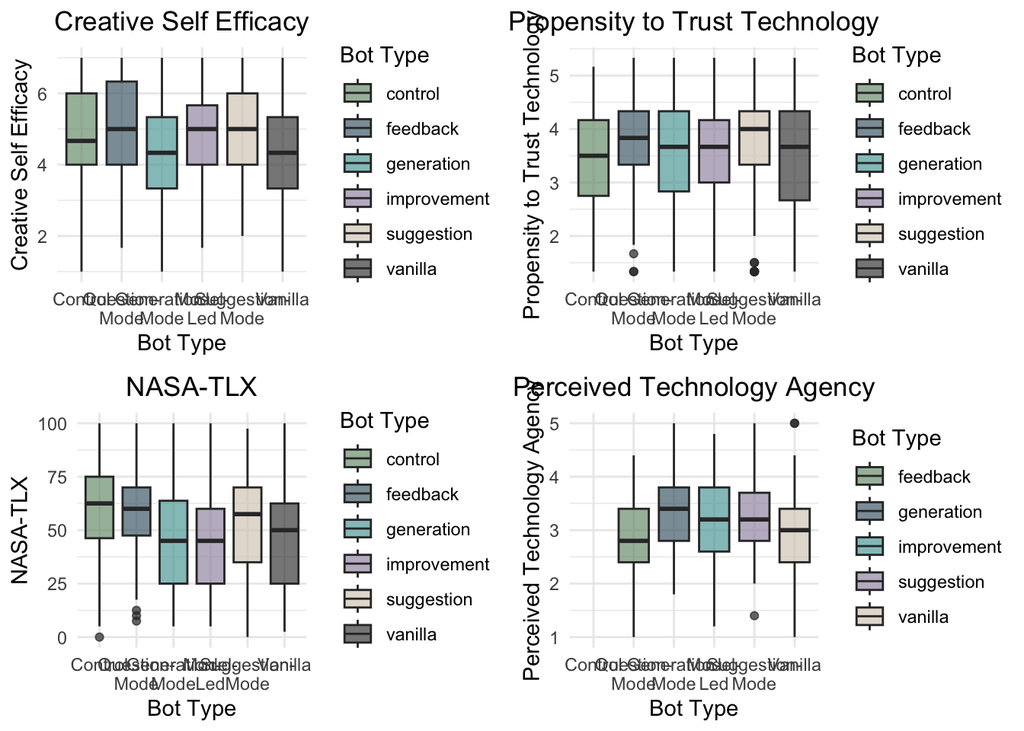

```r
# Function to create simple boxplots
create_boxplot <- function(data, variable, title) {
  ggplot(data, aes(x = bot_type, y = !!sym(variable), fill = bot_type)) +
    geom_boxplot(alpha = 0.7) +
    scale_x_discrete(labels = boxplot_label_map) +
    scale_fill_discrete(name = "Bot Type") +
    labs(title = title,
         x = "Bot Type",
         y = title) +
    theme_minimal() +
    theme(axis.text.x = element_text(angle = 0, hjust = 0.5),
          plot.title = element_text(hjust = 0.5))
}

# Create boxplots for all dependent variables
p1 <- create_boxplot(data_full, "Creative_Self_Efficacy", "Creative Self Efficacy")
p2 <- create_boxplot(data_full, "Propensity_to_Trust_Technology", "Propensity to Trust Technology")
p3 <- create_boxplot(data_full, "NASA_TLX", "NASA-TLX")
p4 <- create_boxplot(data_full, "Perceived_Technology_Agency", "Perceived Technology Agency")
p5 <- create_boxplot(data_full, "Performance_Expectancy", "Performance Expectancy")
p6 <- create_boxplot(data_full, "Effort_Expectancy", "Effort Expectancy")
p7 <- create_boxplot(data_full, "Hedonic_Motivation", "Hedonic Motivation")
p8 <- create_boxplot(data_full, "Perceived_Ownership", "Perceived Ownership")
p9 <- create_boxplot(data_full, "refined_div_allideas", "Idea Diversity - to All")
p10 <- create_boxplot(data_full, "refined_div_condition", "Idea Diversity - within Condition")
p11 <- create_boxplot(data_full, "idea_div_allideas", "Initial Ideas - Diversity to All")
p12 <- create_boxplot(data_full, "idea_div_condition", "Initial Ideas - Diversity within Condition")

# Logit-transformed diversity boxplots
p13 <- create_boxplot(data_full, "refined_div_allideas_logit", "Idea Diversity - to All (Logit)")
p14 <- create_boxplot(data_full, "refined_div_condition_logit", "Idea Diversity - within Condition (Logit)")
p15 <- create_boxplot(data_full, "idea_div_allideas_logit", "Initial Ideas - Diversity to All (Logit)")
p16 <- create_boxplot(data_full, "idea_div_condition_logit", "Initial Ideas - Diversity within Condition (Logit)")

# Display all boxplots
# Display and export the 4 combined plots
plot1 <- grid.arrange(p1, p2, p3, p4, ncol = 2)
```

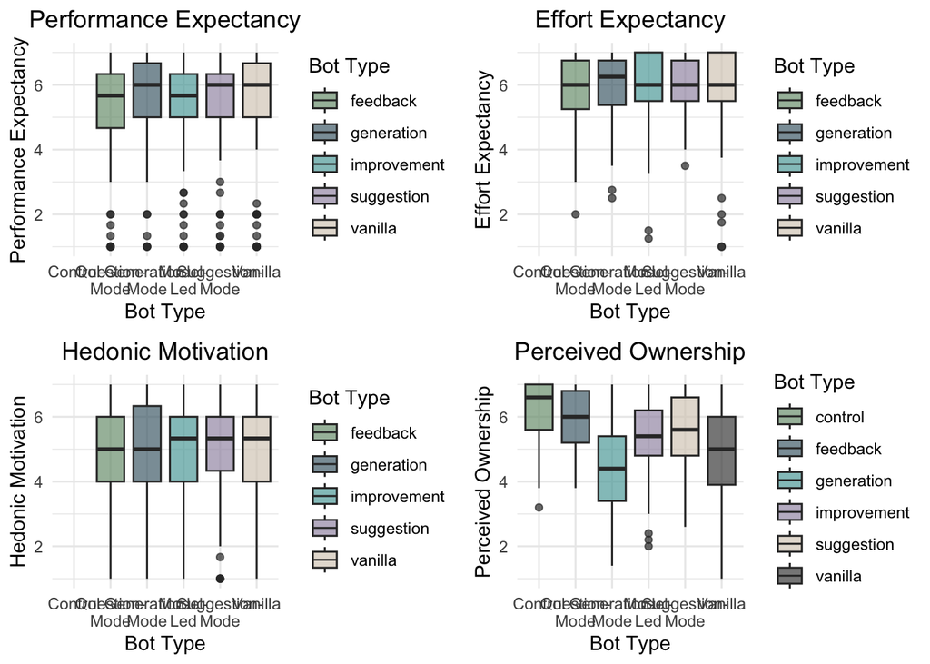

```r
ggsave(fig_path("Questionnaire_Set1.png"), plot1, width = 16, height = 12, dpi = 300)

plot2 <- grid.arrange(p5, p6, p7, p8, ncol = 2)
```

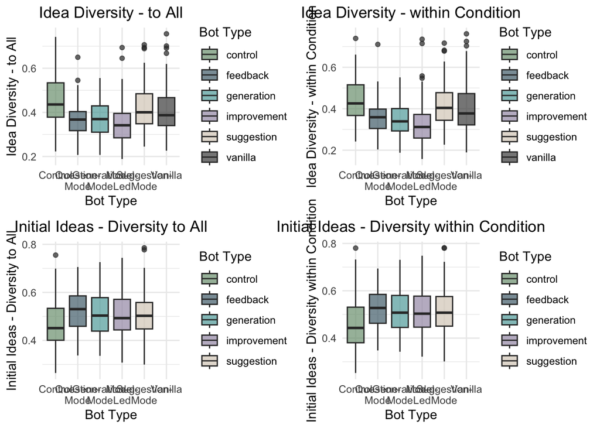

```r
ggsave(fig_path("Questionnaire_Set2.png"), plot2, width = 16, height = 12, dpi = 300)

plot3 <- grid.arrange(p9, p10, p11, p12, ncol = 2)
```

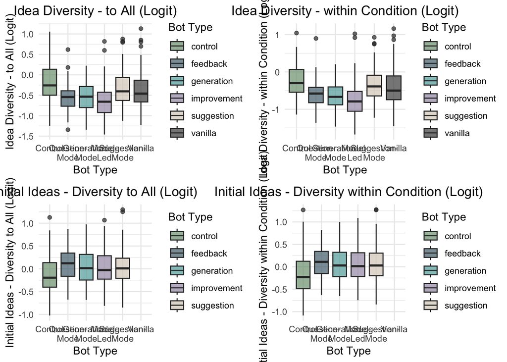

```r
ggsave(fig_path("Diversity_Main.png"), plot3, width = 16, height = 12, dpi = 300)

plot4 <- grid.arrange(p13, p14, p15, p16, ncol = 2)
```

```r
ggsave(fig_path("Diversity_Logit.png"), plot4, width = 16, height = 12, dpi = 300)
```

# Demographics Participants

```r
# Age Analysis
Age <- data_full %>%
  dplyr::select(Age) %>%
  summarise(
    mean_Age = mean(Age, na.rm = TRUE),
    SD_Age = sd(Age, na.rm = TRUE)
  )
Age
```

```
##   mean_Age   SD_Age
## 1 42.16013 13.49363
```

```r
# Age range
youngest <- data_full %>%
  summarise(youngest = min(Age, na.rm = TRUE))

oldest <- data_full %>%
  summarise(oldest = max(Age, na.rm = TRUE))

print(youngest)
```

```
##   youngest
## 1       19
```

```r
print(oldest)
```

```
##   oldest
## 1     79
```

```r
# Gender Analysis
gender_summary <- table(data_full$Sex, useNA = "no")
print(gender_summary)
```

```
##
##            Female              Male Prefer not to say
##               335               298                 3
```

```r
# Additional demographic analyses:

# Gender proportions
gender_proportions <- prop.table(table(data_full$Sex, useNA = "no"))
print(gender_proportions)
```

```
##
##            Female              Male Prefer not to say
##       0.526729560       0.468553459       0.004716981
```

```r
# Gender percentages (as percentages)
gender_percentages <- prop.table(table(data_full$Sex, useNA = "no")) * 100
print(gender_percentages)
```

```
##
##            Female              Male Prefer not to say
##        52.6729560        46.8553459         0.4716981
```

```r
# Ethnicity summary
ethnicity_summary <- table(data_full$Ethnicity.simplified, useNA = "no")
print(ethnicity_summary)
```

```
##
## Asian Black Mixed Other White
##    35    37    21     5   536
```

```r
# Employment status
employment_summary <- table(data_full$Employment.status, useNA = "no")
print(employment_summary)
```

```
##
##             Due to start a new job within the next month
##                                                        6
##                                                Full-Time
##                                                      328
## Not in paid work (e.g. homemaker', 'retired or disabled)
##                                                       72
##                                                    Other
##                                                       20
##                                                Part-Time
##                                                      105
##                             Unemployed (and job seeking)
##                                                       28
```

```r
# Student status
student_summary <- table(data_full$Student.status, useNA = "no")
print(student_summary)
```

```
##
##  No Yes
## 480  71
```

```r
# Country of residence
country_summary <- table(data_full$Country.of.residence, useNA = "no")
print(country_summary)
```

```
##
## United Kingdom
##            637
```

```r
# Country of birth
country_birth_summary <- table(data_full$Country.of.birth, useNA = "no")
print(country_birth_summary)
```

```
##
##         Australia           Belgium            Brazil Brunei Darussalam
##                 2                 2                 1                 1
##            Canada           Estonia           Germany             India
##                 3                 1                 3                 1
##           Ireland             Italy           Jamaica             Kenya
##                 4                 2                 1                 2
##         Lithuania       Netherlands       New Zealand           Nigeria
##                 1                 1                 2                15
##          Pakistan       Philippines            Poland          Portugal
##                 4                 1                 1                 1
##      South Africa    United Kingdom     United States          Zimbabwe
##                 5               578                 2                 3
```

```r
# Nationality
nationality_summary <- table(data_full$Nationality, useNA = "no")
print(nationality_summary)
```

```
##
##         Canada         France        Germany          India        Ireland
##              3              2              1              2              4
##          Italy          Kenya    Netherlands        Nigeria       Pakistan
##              1              1              1             15              3
##       Portugal   South Africa United Kingdom       Zimbabwe
##              1              2            598              1
```

```r
# Language
language_summary <- table(data_full$Language, useNA = "no")
print(language_summary)
```

```
##
## English
##     637
```

```r
# Age distribution by gender
age_by_gender <- data_full %>%
  filter(!is.na(Sex)) %>%
  group_by(Sex) %>%
  summarise(
    mean_age = mean(Age, na.rm = TRUE),
    sd_age = sd(Age, na.rm = TRUE),
    min_age = min(Age, na.rm = TRUE),
    max_age = max(Age, na.rm = TRUE),
    n = n_distinct(study_id)  # Count unique participants
  )
print(age_by_gender)
```

```
## # A tibble: 3 × 6
##   Sex               mean_age sd_age min_age max_age     n
##   <chr>                <dbl>  <dbl>   <dbl>   <dbl> <int>
## 1 Female                42.1  12.9       19      77   280
## 2 Male                  42.4  14.1       19      79   255
## 3 Prefer not to say     26.3   3.06      23      29     3
```

```r
# Demographics by experimental condition (bot_type)
demographics_by_condition <- data_full %>%
  group_by(bot_type) %>%
  summarise(
    n_participants = n_distinct(study_id),
    mean_age = mean(Age, na.rm = TRUE),
    sd_age = sd(Age, na.rm = TRUE),
    min_age = min(Age, na.rm = TRUE),
    max_age = max(Age, na.rm = TRUE),
    .groups = 'drop'
  )
print(demographics_by_condition)
```

```
## # A tibble: 6 × 6
##   bot_type    n_participants mean_age sd_age min_age max_age
##   <chr>                <int>    <dbl>  <dbl>   <dbl>   <dbl>
## 1 control                 91     43.2   14.6      19      77
## 2 feedback                92     44.7   13.6      19      78
## 3 generation              96     40.1   14.7      19      79
## 4 improvement            142     41.0   12.2      19      70
## 5 suggestion              91     41.1   12.1      22      72
## 6 vanilla                 90     43.6   13.9      20      74
```

```r
# Gender distribution by condition
gender_by_condition <- table(data_full$bot_type, data_full$Sex, useNA = "no")
print(gender_by_condition)
```

```
##
##               Female Male Prefer not to say
##   control         55   44                 0
##   feedback        49   46                 2
##   generation      51   47                 1
##   improvement     78   71                 0
##   suggestion      49   50                 0
##   vanilla         53   40                 0
```

```r
# Ethnicity by condition
ethnicity_by_condition <- table(data_full$bot_type, data_full$Ethnicity.simplified, useNA = "no")
print(ethnicity_by_condition)
```

```
##
##               Asian Black Mixed Other White
##   control         3     5     2     0    89
##   feedback        7     3     3     1    83
##   generation      6     7     3     2    81
##   improvement    11     6     3     1   127
##   suggestion      5    10     4     1    79
##   vanilla         3     6     6     0    77
```

```r
# Employment status by condition
employment_by_condition <- table(data_full$bot_type, data_full$Employment.status, useNA = "no")
print(employment_by_condition)
```

```
##
##               Due to start a new job within the next month Full-Time
##   control                                                0        50
##   feedback                                               1        42
##   generation                                             1        53
##   improvement                                            1        82
##   suggestion                                             1        56
##   vanilla                                                2        45
##
##               Not in paid work (e.g. homemaker', 'retired or disabled) Other
##   control                                                           11     6
##   feedback                                                          13     6
##   generation                                                        14     1
##   improvement                                                       14     3
##   suggestion                                                        11     1
##   vanilla                                                            9     3
##
##               Part-Time Unemployed (and job seeking)
##   control            13                           10
##   feedback           16                            3
##   generation         15                            1
##   improvement        28                            7
##   suggestion         15                            2
##   vanilla            18                            5
```

# ICC Ratings

based on: Putka, D. J., Le, H., McCloy, R. A., & Diaz, T. (2008). Ill-structured measurement designs in organizational research: Implications for estimating interrater reliability. Journal of Applied Psychology, 93(5), 959–981. https://doi.org/10.1037/0021-9010.93.5.959

```r
# ICC calculation for partially crossed design (not all raters rate all ideas)
# Using mixed-effects models to extract variance components

# Prepare data with combined idea quality (using only honest evaluators)
data_evaluators_icc <- data_evaluators_honest %>%
  mutate(idea_quality = (originality + usefulness) / 2) %>%
  filter(!is.na(originality), !is.na(usefulness), !is.na(idea_quality))

# Calculate design characteristics for Putka et al. (2008) approach
# k = harmonic mean of raters per idea
raters_per_idea <- data_evaluators_icc %>%
  group_by(idea_id) %>%
  summarise(n_raters = n()) %>%
  pull(n_raters)

k_harmonic <- 1 / mean(1 / raters_per_idea)

# N_total = total number of unique raters in the study
N_total <- data_evaluators_icc %>%
  summarise(n_raters = n_distinct(evaluator_study_id)) %>%
  pull(n_raters)

# Calculate q-multiplier for randomly assigned raters (Putka et al., 2008, Equation 6)
q_multiplier <- (1 / k_harmonic) - (1 / N_total)

# Function to calculate ICC from mixed-effects model using Putka et al. (2008)
calculate_icc_putka <- function(model, k, q, N_total) {
  # Extract variance components
  vc <- as.data.frame(VarCorr(model))

  var_idea <- vc$vcov[vc$grp == "idea_id"]
  var_rater <- vc$vcov[vc$grp == "evaluator_study_id"]
  var_residual <- vc$vcov[vc$grp == "Residual"]

  # ICC for single rating (how reliable is one random rater?)
  icc_single <- var_idea / (var_idea + var_rater + var_residual)

  # G(q,k) for partially crossed design (accounts for rater overlap)
  # Using Putka et al. (2008) Equation 6 with q-multiplier for random assignment
  # q = 1/k - 1/N_total adjusts rater variance contribution based on design overlap
  icc_average <- var_idea / (var_idea + (q * var_rater + var_residual/k))

  return(list(
    var_idea = var_idea,
    var_rater = var_rater,
    var_residual = var_residual,
    icc_single = icc_single,
    icc_average = icc_average,
    k = k,
    N_total = N_total,
    q = q
  ))
}

# Fit model for idea quality
model_quality <- lmer(idea_quality ~ 1 + (1|idea_id) + (1|evaluator_study_id),
                      data = data_evaluators_icc,
                      REML = FALSE)

# Calculate ICC for idea quality using Putka et al. (2008) approach
icc_qual <- calculate_icc_putka(model_quality, k_harmonic, q_multiplier, N_total)

# Summary table
icc_summary <- data.frame(
  Measure = "Idea Quality",
  ICC_single = round(icc_qual$icc_single, 3),
  ICC_average_G_qk = round(icc_qual$icc_average, 3),
  k = round(icc_qual$k, 2),
  N_total = icc_qual$N_total,
  q = round(icc_qual$q, 4)
)
icc_summary
```

```
##        Measure ICC_single ICC_average_G_qk    k N_total      q
## 1 Idea Quality      0.185             0.69 9.73     258 0.0989
```

# Descriptives

```r
# Create correlation matrix with your study variables
correlation_matrix <- data_full %>%
  dplyr::select(c(
    # Questionnaire constructs
    Idea_Quality,
    originality_mean,
    usefulness_mean,
    purchase_intent_mean,
    Perceived_Ownership,
    refined_div_condition,
    Creative_Self_Efficacy,
    Propensity_to_Trust_Technology,
    NASA_TLX,
    Perceived_Technology_Agency,
    Performance_Expectancy,
    Effort_Expectancy,
    Hedonic_Motivation,
    ai1,
    Age,
    total_study_time_seconds
  )) %>%
  mutate(across(everything(), as.numeric))

# Create custom variable names for display
var_names <- c(
  "1. Idea Quality",
  "2. Originality",
  "3. Usefulness",
  "4. Purchase Intent",
  "5. Perceived Ownership",
  "6. Refined Sim Condition Ideas",
  "7. Creative Self-Efficacy",
  "8. Propensity to Trust Technology",
  "9. NASA TLX",
  "10. Perceived Technology Agency",
  "11. Performance Expectancy",
  "12. Effort Expectancy",
  "13. Hedonic Motivation",
  "14. LLM Experience",
  "15. Age",
  "16. Total Study Time (Seconds)"
)

# Calculate correlations with significance tests
cor_result <- corr.test(correlation_matrix, use = "complete")
cor_matrix <- cor_result$r
p_matrix <- cor_result$p

# Create significance indicators
sig_matrix <- ifelse(p_matrix < 0.01, "**",
                    ifelse(p_matrix < 0.05, "*", ""))

# Format correlation matrix for display
cor_display <- cor_matrix
diag(cor_display) <- NA  # Remove diagonal
cor_display[lower.tri(cor_display)] <- NA  # Remove lower triangle

# Create formatted correlation strings
cor_formatted <- matrix("", nrow = nrow(cor_matrix), ncol = ncol(cor_matrix))
for(i in 1:nrow(cor_matrix)) {
  for(j in 1:ncol(cor_matrix)) {
    if(!is.na(cor_display[i,j])) {
      cor_formatted[i,j] <- paste0(sprintf("%.2f", cor_matrix[i,j]), sig_matrix[i,j])
    } else if(i == j) {
      cor_formatted[i,j] <- "---"
    }
  }
}

# Set row and column names
rownames(cor_formatted) <- var_names
colnames(cor_formatted) <- 1:ncol(cor_matrix)

# Calculate descriptive statistics
means <- sapply(correlation_matrix, mean, na.rm = TRUE)
sds <- sapply(correlation_matrix, sd, na.rm = TRUE)

# Create descriptive stats table
desc_stats <- data.frame(
  Variable = var_names,
  M = sprintf("%.2f", means),
  SD = sprintf("%.2f", sds),
  stringsAsFactors = FALSE
)

# Export correlation matrix as LaTeX
stargazer(cor_formatted,
          type = "latex",
          title = "Means, standard deviations, and correlations with confidence intervals",
          label = "tab:correlations",
          out = fig_path("correlation_table.tex"),
          summary = FALSE,
          rownames = TRUE,
          digits = 2,
          font.size = "footnotesize",
          table.placement = "H",
          header = FALSE,
          notes = c("\\textit{M} and \\textit{SD} represent mean and standard deviation, respectively.",
                   "Values in square brackets indicate 95\\% confidence intervals.",
                   "* indicates \\textit{p} < .05; ** indicates \\textit{p} < .01."),
          notes.align = "l")
```

[output not shown]

```r
# Also create a version with descriptive statistics
# Combine descriptives and correlations
desc_cor_combined <- cbind(desc_stats, cor_formatted)

stargazer(desc_cor_combined,
          type = "latex",
          title = "Means, standard deviations, and correlations with confidence intervals",
          label = "tab:correlations_full",
          out = fig_path("correlation_table_full.tex"),
          summary = FALSE,
          rownames = FALSE,
          digits = 2,
          font.size = "scriptsize",
          table.placement = "H",
          header = FALSE,
          notes = c("\\textit{M} and \\textit{SD} represent mean and standard deviation, respectively.",
                   "* indicates \\textit{p} < .05; ** indicates \\textit{p} < .01."),
          notes.align = "l")
```

```
##
## \begin{table}[H] \centering
##   \caption{Means, standard deviations, and correlations with confidence intervals}
##   \label{tab:correlations_full}
## \scriptsize
## \begin{tabular}{@{\extracolsep{5pt}} ccccccccccccccccccc}
## \\[-1.8ex]\hline
## \hline \\[-1.8ex]
## Variable & M & SD & 1 & 2 & 3 & 4 & 5 & 6 & 7 & 8 & 9 & 10 & 11 & 12 & 13 & 14 & 15 & 16 \\
## \hline \\[-1.8ex]
## 1. Idea Quality & 4.15 & 0.77 & --- & 0.79\textasteriskcentered \textasteriskcentered  & 0.80\textasteriskcentered \textasteriskcentered  & 0.69\textasteriskcentered \textasteriskcentered  & 0.01 & -0.37\textasteriskcentered \textasteriskcentered  & 0.01 & 0.09 & -0.01 & 0.01 & 0.09 & 0.08 & 0.08…
## 2. Originality & 4.16 & 0.98 &  & --- & 0.25\textasteriskcentered \textasteriskcentered  & 0.28\textasteriskcentered \textasteriskcentered  & 0.02 & -0.23\textasteriskcentered \textasteriskcentered  & 0.05 & 0.10 & -0.00 & 0.02 & 0.09 & 0.08 & 0.08 & 0.03 & -0.01 & -0.15 \\
## 3. Usefulness & 4.13 & 0.96 &  &  & --- & 0.81\textasteriskcentered \textasteriskcentered  & -0.01 & -0.36\textasteriskcentered \textasteriskcentered  & -0.04 & 0.05 & -0.02 & -0.00 & 0.05 & 0.05 & 0.04 & 0.03 & 0.01 & 0.00 \\
## 4. Purchase Intent & 2.36 & 0.56 &  &  &  & --- & 0.02 & -0.24\textasteriskcentered \textasteriskcentered  & -0.01 & 0.03 & -0.01 & -0.02 & 0.03 & 0.05 & 0.01 & 0.02 & 0.02 & -0.01 \\
## 5. Perceived Ownership & 5.38 & 1.30 &  &  &  &  & --- & 0.16\textasteriskcentered  & 0.62\textasteriskcentered \textasteriskcentered  & 0.06 & 0.24\textasteriskcentered \textasteriskcentered  & -0.18\textasteriskcentered \textasteriskcentered  & -0.13 & 0.06 & -0.00 & 0.05 & 0.13 & 0.16\textaste…
## 6. Refined Sim Condition Ideas & 0.38 & 0.10 &  &  &  &  &  & --- & 0.08 & -0.06 & 0.07 & 0.01 & -0.19\textasteriskcentered \textasteriskcentered  & -0.12 & -0.11 & -0.02 & 0.07 & 0.16\textasteriskcentered  \\
## 7. Creative Self-Efficacy & 4.72 & 1.44 &  &  &  &  &  &  & --- & 0.14 & 0.16\textasteriskcentered  & -0.06 & -0.00 & 0.16\textasteriskcentered  & 0.13 & 0.10 & 0.04 & 0.14 \\
## 8. Propensity to Trust Technology & 3.57 & 0.95 &  &  &  &  &  &  &  & --- & 0.04 & 0.08 & 0.52\textasteriskcentered \textasteriskcentered  & 0.37\textasteriskcentered \textasteriskcentered  & 0.62\textasteriskcentered \textasteriskcentered  & 0.52\textasteriskcentered \textasteriskcentered  & -0…
## 9. NASA TLX & 50.29 & 22.82 &  &  &  &  &  &  &  &  & --- & -0.03 & 0.03 & -0.08 & 0.03 & 0.01 & 0.15\textasteriskcentered  & 0.25\textasteriskcentered \textasteriskcentered  \\
## 10. Perceived Technology Agency & 3.14 & 0.74 &  &  &  &  &  &  &  &  &  & --- & 0.07 & 0.03 & 0.10 & -0.05 & -0.02 & -0.15\textasteriskcentered  \\
## 11. Performance Expectancy & 5.38 & 1.54 &  &  &  &  &  &  &  &  &  &  & --- & 0.64\textasteriskcentered \textasteriskcentered  & 0.74\textasteriskcentered \textasteriskcentered  & 0.34\textasteriskcentered \textasteriskcentered  & -0.10 & 0.03 \\
## 12. Effort Expectancy & 5.96 & 1.03 &  &  &  &  &  &  &  &  &  &  &  & --- & 0.59\textasteriskcentered \textasteriskcentered  & 0.34\textasteriskcentered \textasteriskcentered  & -0.14 & -0.01 \\
## 13. Hedonic Motivation & 4.99 & 1.60 &  &  &  &  &  &  &  &  &  &  &  &  & --- & 0.38\textasteriskcentered \textasteriskcentered  & -0.04 & -0.00 \\
## 14. LLM Experience & 3.25 & 1.25 &  &  &  &  &  &  &  &  &  &  &  &  &  & --- & -0.21\textasteriskcentered \textasteriskcentered  & 0.01 \\
## 15. Age & 42.16 & 13.49 &  &  &  &  &  &  &  &  &  &  &  &  &  &  & --- & 0.14 \\
## 16. Total Study Time (Seconds) & 424.52 & 332.62 &  &  &  &  &  &  &  &  &  &  &  &  &  &  &  & --- \\
## \hline \\[-1.8ex]
## \multicolumn{19}{l}{\textit{M} and \textit{SD} represent mean and standard deviation, respectively.} \\
## \multicolumn{19}{l}{* indicates \textit{p} < .05; ** indicates \textit{p} < .01.} \\
## \end{tabular}
## \end{table}
```

```r
# Print summary for console
cat("Correlation table exported to:", fig_path("correlation_table.tex"), "\n")
```

```
## Correlation table exported to: /Users/rudimaier/DevProjekte/CreativityExperimentAGH/analysis/Study2/Figures/correlation_table.tex
```

```r
cat("Full table with descriptives exported to:", fig_path("correlation_table_full.tex"), "\n")
```

```
## Full table with descriptives exported to: /Users/rudimaier/DevProjekte/CreativityExperimentAGH/analysis/Study2/Figures/correlation_table_full.tex
```

#Reliabilitäten # Creative Self-Efficacy

```r
CreativeSelfEfficacy <- data_full %>%
  dplyr::select(., c(cse1, cse2, cse3))
alpha_CreativeSelfEfficacy <- psych::alpha(CreativeSelfEfficacy, check.keys = TRUE)
print(alpha_CreativeSelfEfficacy)
```

```
##
## Reliability analysis
## Call: psych::alpha(x = CreativeSelfEfficacy, check.keys = TRUE)
##
##   raw_alpha std.alpha G6(smc) average_r S/N    ase mean  sd median_r
##       0.89      0.89    0.85      0.74 8.5 0.0073  4.7 1.4     0.71
##
##     95% confidence boundaries
##          lower alpha upper
## Feldt     0.88  0.89  0.91
## Duhachek  0.88  0.89  0.91
##
##  Reliability if an item is dropped:
##      raw_alpha std.alpha G6(smc) average_r S/N alpha se var.r med.r
## cse1      0.83      0.83    0.71      0.71 5.0    0.013    NA  0.71
## cse2      0.83      0.83    0.71      0.71 4.8    0.014    NA  0.71
## cse3      0.88      0.89    0.80      0.80 7.9    0.009    NA  0.80
##
##  Item statistics
##        n raw.r std.r r.cor r.drop mean  sd
## cse1 640  0.92  0.92  0.87   0.81  4.7 1.7
## cse2 640  0.92  0.92  0.87   0.82  5.0 1.5
## cse3 640  0.89  0.89  0.79   0.75  4.4 1.6
##
## Non missing response frequency for each item
##         1    2    3    4    5    6    7 miss
## cse1 0.04 0.08 0.13 0.16 0.24 0.16 0.19    0
## cse2 0.02 0.05 0.07 0.19 0.28 0.20 0.19    0
## cse3 0.05 0.07 0.14 0.25 0.24 0.14 0.11    0
```

# Perceived Technology Agency

```r
PerceivedTechnologyAgency <- data_full %>%
  dplyr::select(., c(pta1, pta2, pta3, pta4, pta5))
alpha_PerceivedTechnologyAgency <- psych::alpha(PerceivedTechnologyAgency, check.keys = TRUE)
print(alpha_PerceivedTechnologyAgency)
```

```
##
## Reliability analysis
## Call: psych::alpha(x = PerceivedTechnologyAgency, check.keys = TRUE)
##
##   raw_alpha std.alpha G6(smc) average_r S/N   ase mean   sd median_r
##       0.75      0.74    0.74      0.37 2.9 0.015  3.1 0.74     0.37
##
##     95% confidence boundaries
##          lower alpha upper
## Feldt     0.72  0.75  0.78
## Duhachek  0.72  0.75  0.78
##
##  Reliability if an item is dropped:
##      raw_alpha std.alpha G6(smc) average_r S/N alpha se var.r med.r
## pta1      0.68      0.68    0.63      0.34 2.1    0.020 0.020  0.35
## pta2      0.65      0.64    0.59      0.31 1.8    0.022 0.015  0.31
## pta3      0.72      0.71    0.70      0.38 2.4    0.018 0.045  0.35
## pta4      0.79      0.78    0.76      0.48 3.6    0.014 0.018  0.45
## pta5      0.68      0.67    0.66      0.33 2.0    0.020 0.045  0.26
##
##  Item statistics
##        n raw.r std.r r.cor r.drop mean   sd
## pta1 541  0.76  0.74  0.70   0.58  3.0 1.07
## pta2 541  0.82  0.80  0.79   0.66  3.0 1.13
## pta3 541  0.69  0.69  0.56   0.49  3.6 1.02
## pta4 541  0.49  0.52  0.30   0.27  3.0 0.93
## pta5 541  0.76  0.76  0.67   0.59  3.0 1.06
##
## Non missing response frequency for each item
##         1    2    3    4    5 miss
## pta1 0.07 0.28 0.32 0.25 0.09 0.15
## pta2 0.09 0.26 0.26 0.31 0.09 0.15
## pta3 0.05 0.10 0.24 0.45 0.16 0.15
## pta4 0.05 0.21 0.48 0.20 0.06 0.15
## pta5 0.07 0.25 0.33 0.27 0.08 0.15
```

# NASA-TLX

```r
NASATLX <- data_full %>%
  dplyr::select(., c(tlx1, tlx2))

# Inter-item Pearson correlation (2-item scale)
nasatlx_test <- cor.test(NASATLX$tlx1, NASATLX$tlx2, method = "pearson")
print(nasatlx_test)
```

```
##
##  Pearson's product-moment correlation
##
## data:  NASATLX$tlx1 and NASATLX$tlx2
## t = 32.615, df = 638, p-value < 2.2e-16
## alternative hypothesis: true correlation is not equal to 0
## 95 percent confidence interval:
##  0.7596731 0.8180040
## sample estimates:
##       cor
## 0.7906256
```

# Performance Expectancy

```r
PerformanceExpectancy <- data_full %>%
  dplyr::select(., c(pe1, pe2, pe3))
alpha_PerformanceExpectancy <- psych::alpha(PerformanceExpectancy, check.keys = TRUE)
print(alpha_PerformanceExpectancy)
```

```
##
## Reliability analysis
## Call: psych::alpha(x = PerformanceExpectancy, check.keys = TRUE)
##
##   raw_alpha std.alpha G6(smc) average_r S/N    ase mean  sd median_r
##       0.96      0.96    0.95       0.9  26 0.0025  5.4 1.5      0.9
##
##     95% confidence boundaries
##          lower alpha upper
## Feldt     0.96  0.96  0.97
## Duhachek  0.96  0.96  0.97
##
##  Reliability if an item is dropped:
##     raw_alpha std.alpha G6(smc) average_r S/N alpha se var.r med.r
## pe1      0.95      0.95    0.90      0.90  18   0.0041    NA  0.90
## pe2      0.95      0.95    0.90      0.90  18   0.0041    NA  0.90
## pe3      0.94      0.94    0.89      0.89  16   0.0046    NA  0.89
##
##  Item statistics
##       n raw.r std.r r.cor r.drop mean  sd
## pe1 541  0.96  0.96  0.94   0.92  5.4 1.6
## pe2 541  0.97  0.96  0.94   0.92  5.4 1.6
## pe3 541  0.97  0.97  0.95   0.93  5.4 1.6
##
## Non missing response frequency for each item
##        1    2    3    4    5    6    7 miss
## pe1 0.04 0.05 0.02 0.07 0.24 0.34 0.24 0.15
## pe2 0.05 0.05 0.03 0.08 0.21 0.31 0.27 0.15
## pe3 0.05 0.04 0.04 0.07 0.23 0.32 0.26 0.15
```

# Effort Expectancy

```r
EffortExpectancy <- data_full %>%
  dplyr::select(., c(ee1, ee2, ee3, ee4))
alpha_EffortExpectancy <- psych::alpha(EffortExpectancy, check.keys = TRUE)
print(alpha_EffortExpectancy)
```

```
##
## Reliability analysis
## Call: psych::alpha(x = EffortExpectancy, check.keys = TRUE)
##
##   raw_alpha std.alpha G6(smc) average_r S/N    ase mean sd median_r
##       0.93      0.93    0.91      0.76  13 0.0047    6  1     0.77
##
##     95% confidence boundaries
##          lower alpha upper
## Feldt     0.92  0.93  0.94
## Duhachek  0.92  0.93  0.94
##
##  Reliability if an item is dropped:
##     raw_alpha std.alpha G6(smc) average_r  S/N alpha se   var.r med.r
## ee1      0.92      0.92    0.88      0.79 11.2   0.0057 0.00002  0.79
## ee2      0.90      0.90    0.86      0.74  8.7   0.0071 0.00185  0.75
## ee3      0.90      0.90    0.86      0.74  8.7   0.0070 0.00206  0.75
## ee4      0.91      0.91    0.87      0.76  9.6   0.0064 0.00069  0.75
##
##  Item statistics
##       n raw.r std.r r.cor r.drop mean  sd
## ee1 541  0.88  0.88  0.82   0.79  6.1 1.1
## ee2 541  0.92  0.92  0.89   0.85  6.0 1.1
## ee3 541  0.92  0.92  0.88   0.85  6.0 1.1
## ee4 541  0.91  0.90  0.86   0.83  5.8 1.2
##
## Non missing response frequency for each item
##        1    2    3    4    5    6    7 miss
## ee1 0.01 0.01 0.02 0.05 0.15 0.35 0.42 0.15
## ee2 0.01 0.00 0.02 0.06 0.18 0.34 0.38 0.15
## ee3 0.01 0.01 0.01 0.04 0.17 0.35 0.41 0.15
## ee4 0.01 0.01 0.01 0.10 0.21 0.33 0.32 0.15
```

# Hedonic Motivation

```r
HedonicMotivation <- data_full %>%
  dplyr::select(., c(hm1, hm2, hm3))
alpha_HedonicMotivation <- psych::alpha(HedonicMotivation, check.keys = TRUE)
print(alpha_HedonicMotivation)
```

```
##
## Reliability analysis
## Call: psych::alpha(x = HedonicMotivation, check.keys = TRUE)
##
##   raw_alpha std.alpha G6(smc) average_r S/N   ase mean  sd median_r
##       0.97      0.97    0.96      0.92  33 0.002    5 1.6     0.91
##
##     95% confidence boundaries
##          lower alpha upper
## Feldt     0.97  0.97  0.97
## Duhachek  0.97  0.97  0.97
##
##  Reliability if an item is dropped:
##     raw_alpha std.alpha G6(smc) average_r S/N alpha se var.r med.r
## hm1      0.95      0.95    0.91      0.91  21   0.0036    NA  0.91
## hm2      0.96      0.96    0.93      0.93  25   0.0031    NA  0.93
## hm3      0.95      0.95    0.91      0.91  21   0.0037    NA  0.91
##
##  Item statistics
##       n raw.r std.r r.cor r.drop mean  sd
## hm1 541  0.97  0.97  0.95   0.94  5.0 1.7
## hm2 541  0.97  0.97  0.94   0.93  4.8 1.7
## hm3 541  0.97  0.97  0.95   0.94  5.1 1.6
##
## Non missing response frequency for each item
##        1    2    3    4    5    6    7 miss
## hm1 0.05 0.05 0.06 0.15 0.23 0.25 0.21 0.15
## hm2 0.06 0.06 0.07 0.18 0.26 0.18 0.19 0.15
## hm3 0.04 0.05 0.05 0.15 0.24 0.26 0.21 0.15
```

# Propensity to Trust Technology

```r
PropensityTrustTechnology <- data_full %>%
  dplyr::select(., c(ptt1, ptt2_rev, ptt3, ptt4, ptt5, ptt6))
alpha_PropensityTrustTechnology <- psych::alpha(PropensityTrustTechnology, check.keys = TRUE)
print(alpha_PropensityTrustTechnology)
```

```
##
## Reliability analysis
## Call: psych::alpha(x = PropensityTrustTechnology, check.keys = TRUE)
##
##   raw_alpha std.alpha G6(smc) average_r S/N    ase mean   sd median_r
##       0.93      0.93    0.92      0.68  13 0.0047  3.6 0.95     0.68
##
##     95% confidence boundaries
##          lower alpha upper
## Feldt     0.92  0.93  0.93
## Duhachek  0.92  0.93  0.93
##
##  Reliability if an item is dropped:
##          raw_alpha std.alpha G6(smc) average_r  S/N alpha se  var.r med.r
## ptt1          0.91      0.91    0.90      0.67 10.0   0.0060 0.0139  0.67
## ptt2_rev      0.93      0.93    0.92      0.73 13.6   0.0044 0.0053  0.74
## ptt3          0.92      0.92    0.91      0.70 11.6   0.0052 0.0105  0.72
## ptt4          0.90      0.90    0.89      0.65  9.3   0.0063 0.0083  0.66
## ptt5          0.90      0.90    0.89      0.65  9.2   0.0063 0.0082  0.66
## ptt6          0.91      0.92    0.91      0.68 10.8   0.0056 0.0121  0.70
##
##  Item statistics
##            n raw.r std.r r.cor r.drop mean  sd
## ptt1     640  0.88  0.88  0.86   0.83  3.4 1.1
## ptt2_rev 640  0.76  0.76  0.68   0.65  5.4 1.2
## ptt3     640  0.82  0.82  0.77   0.73  3.2 1.1
## ptt4     640  0.91  0.91  0.91   0.87  3.1 1.1
## ptt5     640  0.92  0.92  0.92   0.87  3.3 1.1
## ptt6     640  0.84  0.85  0.81   0.77  2.9 1.1
##
## Non missing response frequency for each item
##             1    2    3    4    5    6    7 miss
## ptt1     0.06 0.14 0.26 0.41 0.13 0.00 0.00    0
## ptt2_rev 0.00 0.00 0.08 0.17 0.19 0.38 0.18    0
## ptt3     0.09 0.17 0.26 0.36 0.12 0.00 0.00    0
## ptt4     0.10 0.18 0.30 0.34 0.08 0.00 0.00    0
## ptt5     0.07 0.17 0.28 0.38 0.10 0.00 0.00    0
## ptt6     0.11 0.24 0.31 0.28 0.06 0.00 0.00    0
```

# Perceived Ownership

```r
PerceivedOwnership <- data_full %>%
  dplyr::select(., c(io1, io2, io3, io4, io5))
alpha_PerceivedOwnership <- psych::alpha(PerceivedOwnership, check.keys = TRUE)
print(alpha_PerceivedOwnership)
```

```
##
## Reliability analysis
## Call: psych::alpha(x = PerceivedOwnership, check.keys = TRUE)
##
##   raw_alpha std.alpha G6(smc) average_r S/N    ase mean  sd median_r
##       0.89       0.9    0.89      0.63 8.5 0.0066  5.4 1.3      0.6
##
##     95% confidence boundaries
##          lower alpha upper
## Feldt     0.88  0.89  0.91
## Duhachek  0.88  0.89  0.91
##
##  Reliability if an item is dropped:
##     raw_alpha std.alpha G6(smc) average_r S/N alpha se var.r med.r
## io1      0.85      0.86    0.84      0.60 6.0   0.0092 0.019  0.60
## io2      0.84      0.85    0.83      0.59 5.6   0.0100 0.016  0.59
## io3      0.85      0.85    0.83      0.59 5.6   0.0096 0.017  0.57
## io4      0.90      0.89    0.88      0.68 8.5   0.0064 0.016  0.69
## io5      0.90      0.90    0.89      0.70 9.5   0.0067 0.011  0.72
##
##  Item statistics
##       n raw.r std.r r.cor r.drop mean  sd
## io1 640  0.88  0.88  0.86   0.81  5.3 1.5
## io2 640  0.91  0.90  0.90   0.85  5.3 1.6
## io3 640  0.90  0.90  0.89   0.84  5.4 1.5
## io4 640  0.79  0.77  0.68   0.64  4.8 1.8
## io5 640  0.71  0.74  0.63   0.59  6.0 1.3
##
## Non missing response frequency for each item
##        1    2    3    4    5    6    7 miss
## io1 0.02 0.05 0.07 0.11 0.25 0.22 0.29    0
## io2 0.02 0.06 0.07 0.11 0.20 0.24 0.30    0
## io3 0.01 0.06 0.05 0.12 0.23 0.25 0.28    0
## io4 0.05 0.10 0.10 0.15 0.19 0.18 0.24    0
## io5 0.00 0.02 0.03 0.06 0.14 0.24 0.50    0
```

# Reliability Summary

```r
# Cronbach's alpha for multi-item scales (excluding 2-item NASA-TLX)
reliability_summary <- data.frame(
  Scale = c("Creative Self-Efficacy", "Perceived Technology Agency",
           "Performance Expectancy", "Effort Expectancy", "Hedonic Motivation",
           "Propensity to Trust Technology", "Perceived Ownership"),
  Cronbachs_Alpha = c(
    alpha_CreativeSelfEfficacy$total$raw_alpha,
    alpha_PerceivedTechnologyAgency$total$raw_alpha,
    alpha_PerformanceExpectancy$total$raw_alpha,
    alpha_EffortExpectancy$total$raw_alpha,
    alpha_HedonicMotivation$total$raw_alpha,
    alpha_PropensityTrustTechnology$total$raw_alpha,
    alpha_PerceivedOwnership$total$raw_alpha
  ),
  Items = c(3, 5, 3, 4, 3, 6, 5)
)

knitr::kable(reliability_summary, digits = 3, caption = "Cronbach's Alpha for Multi-item Scales")
```

Cronbach’s Alpha for Multi-item Scales

| Scale | Cronbachs_Alpha | Items |
| --- | --- | --- |
| Creative Self-Efficacy | 0.893 | 3 |
| Perceived Technology Agency | 0.752 | 5 |
| Performance Expectancy | 0.963 | 3 |
| Effort Expectancy | 0.926 | 4 |
| Hedonic Motivation | 0.970 | 3 |
| Propensity to Trust Technology | 0.925 | 6 |
| Perceived Ownership | 0.893 | 5 |

```r
# Inter-item Pearson r for NASA-TLX (2 items)
nasatlx_test <- cor.test(data_full$tlx1, data_full$tlx2, method = "pearson")
nasatlx_reliability <- data.frame(
  Scale = "NASA-TLX (2 items)",
  Pearson_r = round(unname(nasatlx_test$estimate), 3),
  CI_low = round(nasatlx_test$conf.int[1], 3),
  CI_high = round(nasatlx_test$conf.int[2], 3),
  p_value = signif(nasatlx_test$p.value, 3)
)
knitr::kable(nasatlx_reliability, digits = 3, caption = "Inter-item Pearson correlation for NASA-TLX")
```

Inter-item Pearson correlation for NASA-TLX

| Scale | Pearson_r | CI_low | CI_high | p_value |
| --- | --- | --- | --- | --- |
| NASA-TLX (2 items) | 0.791 | 0.76 | 0.818 | 0 |

# Regression Assumption Tests

## Build Models for Diagnostics

```r
# Model 1: Idea Quality (Mixed-Effects)
data_evaluators_with_bottype <- data_evaluators_honest %>%
  mutate(idea_quality = (originality + usefulness) / 2) %>%
  filter(!is.na(originality), !is.na(usefulness), !is.na(bot_type))

data_evaluators_with_bottype$bot_type <- factor(
  data_evaluators_with_bottype$bot_type,
  levels = c("feedback", "suggestion", "improvement", "generation", "vanilla", "control")
)

quality_model_mixed <- lmer(
  idea_quality ~ bot_type + (1|idea_id) + (1|evaluator_study_id),
  data = data_evaluators_with_bottype,
  REML = FALSE
)

# Model 2: Idea Diversity (Linear Model)
data_full$bot_type <- factor(data_full$bot_type,
                            levels = c("feedback", "suggestion", "improvement", "generation", "vanilla", "control"))

DIV_model <- lm(refined_div_condition ~ bot_type, data = data_full)

# Model 2b: Idea Diversity with Logit Transformation (Linear Model)
DIV_model_logit <- lm(refined_div_condition_logit ~ bot_type, data = data_full)

# Model 3: Perceived Ownership (Linear Model)
PO_model <- lm(Perceived_Ownership ~ bot_type, data = data_full)
```

## Assumption Tests: Mixed-Effects Model (Idea Quality)

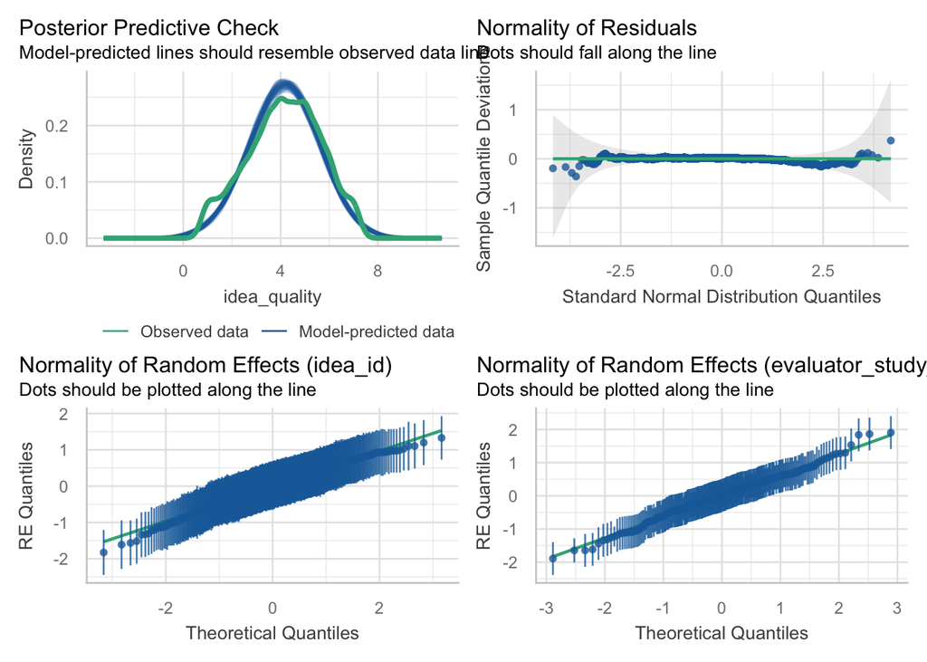

```r
Model1 <-  check_model(
  quality_model_mixed,
  check = c("pp_check", "reqq", "qq")
)
Model1
```

```r
# Save the full check_model composite plot as PDF (large enough for readability)
pdf(fig_path("diagnostics_quality_full_check_model.pdf"), width = 10, height = 8)
plot(Model1)
```

```
## Ignoring unknown labels:
## • size : ""
```

```r
dev.off()
```

## Assumption Tests: Linear Model (Idea Diversity)

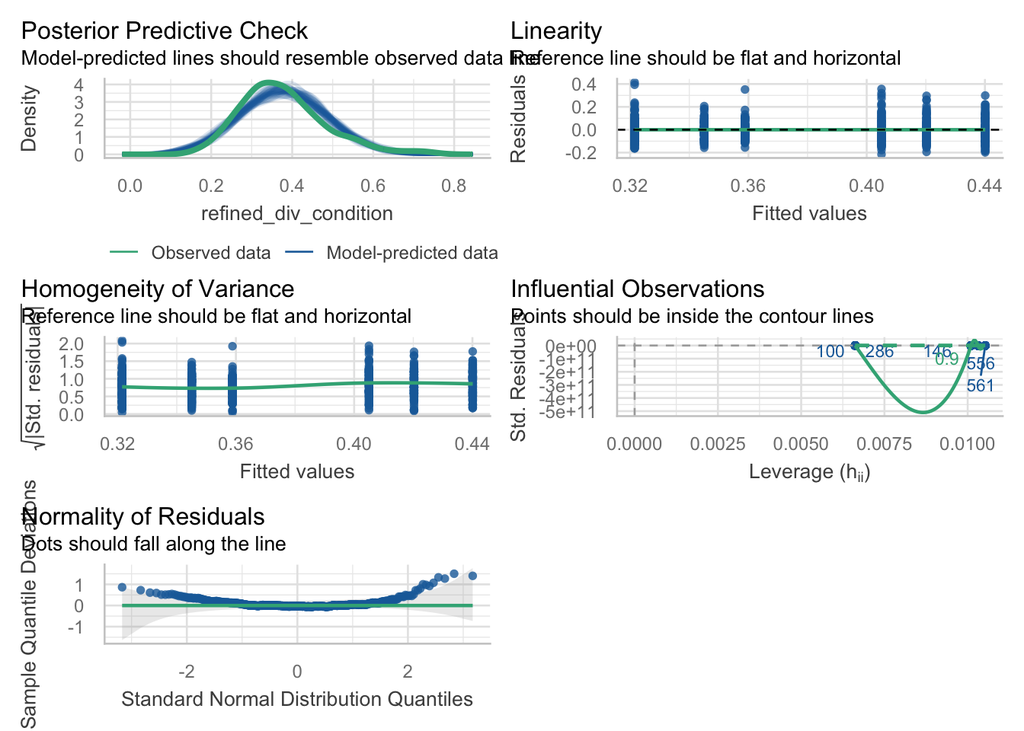

```r
Model_DIV <- check_model(
  DIV_model)
Model_DIV
```

```r
# Save the full check_model composite plot as PDF (large enough for readability)
pdf(fig_path("diagnostics_diversity_full_check_model.pdf"), width = 10, height = 4)
plot(Model_DIV)
```

```
## Ignoring unknown labels:
## • size : ""
```

```r
dev.off()
```

## Assumption Tests: Linear Model (Idea Diversity - Logit Transformed)

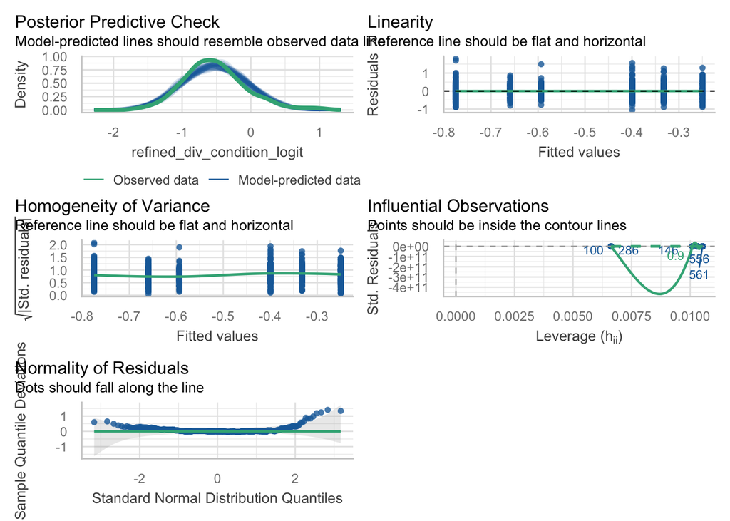

```r
Model_DIV_logit <- check_model(
  DIV_model_logit)
Model_DIV_logit
```

```r
# Save the full check_model composite plot as PDF (large enough for readability)
pdf(fig_path("diagnostics_diversity_logit_full_check_model.pdf"), width = 10, height = 4)
plot(Model_DIV_logit)
```

```
## Ignoring unknown labels:
## • size : ""
```

```r
dev.off()
```

## Assumption Tests: Linear Model (Perceived Ownership)

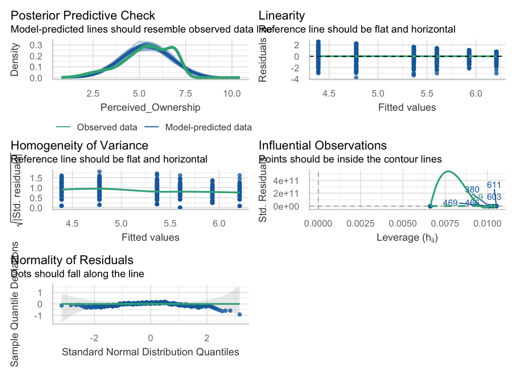

```r
Model_PO <- check_model(
  PO_model)
Model_PO
```

```r
# Save the full check_model composite plot as PDF (large enough for readability)
pdf(fig_path("diagnostics_ownership_full_check_model.pdf"), width = 10, height = 4)
plot(Model_PO)
```

```
## Ignoring unknown labels:
## • size : ""
```

```r
dev.off()
```

## H1: Mixed-Effects Model Accounting for Evaluator Variance

```r
# Model already created in assumption tests section above
print(summary(quality_model_mixed))
```

```
## Linear mixed model fit by maximum likelihood . t-tests use Satterthwaite's
##   method [lmerModLmerTest]
## Formula: idea_quality ~ bot_type + (1 | idea_id) + (1 | evaluator_study_id)
##    Data: data_evaluators_with_bottype
##
##       AIC       BIC    logLik -2*log(L)  df.resid
##   21198.2   21258.9  -10590.1   21180.2      6291
##
## Scaled residuals:
##     Min      1Q  Median      3Q     Max
## -3.7918 -0.6477  0.0102  0.6468  3.9411
##
## Random effects:
##  Groups             Name        Variance Std.Dev.
##  idea_id            (Intercept) 0.3379   0.5813
##  evaluator_study_id (Intercept) 0.4620   0.6797
##  Residual                       1.3669   1.1692
## Number of obs: 6300, groups:  idea_id, 640; evaluator_study_id, 258
##
## Fixed effects:
##                      Estimate Std. Error        df t value Pr(>|t|)
## (Intercept)           4.41206    0.08245 838.26545  53.512  < 2e-16 ***
## bot_typesuggestion   -0.52647    0.09942 643.60828  -5.295 1.63e-07 ***
## bot_typeimprovement   0.00983    0.09060 644.51949   0.109    0.914
## bot_typegeneration   -0.11966    0.09931 640.51332  -1.205    0.229
## bot_typevanilla      -0.65172    0.10050 644.75304  -6.484 1.77e-10 ***
## bot_typecontrol      -0.54800    0.09925 639.39595  -5.521 4.90e-08 ***
## ---
## Signif. codes:  0 '***' 0.001 '**' 0.01 '*' 0.05 '.' 0.1 ' ' 1
##
## Correlation of Fixed Effects:
##             (Intr) bt_typs bt_typm bt_typg bt_typv
## bt_typsggst -0.609
## bt_typmprvm -0.669  0.554
## bt_typgnrtn -0.610  0.505   0.556
## bot_typvnll -0.603  0.501   0.549   0.501
## bt_typcntrl -0.611  0.507   0.556   0.507   0.502
```

```r
vc <- as.data.frame(VarCorr(quality_model_mixed))

# Calculate ICC to show proportion of variance due to clustering
var_idea <- vc$vcov[vc$grp == "idea_id"]
var_rater <- vc$vcov[vc$grp == "evaluator_study_id"]
var_residual <- vc$vcov[vc$grp == "Residual"]
icc_idea <- var_idea / (var_idea + var_rater + var_residual)
icc_rater <- var_rater / (var_idea + var_rater + var_residual)

# Step 3: Extract estimated marginal means
quality_emm_mixed <- emmeans(quality_model_mixed, specs = ~ bot_type)
```

```
## Note: D.f. calculations have been disabled because the number of observations exceeds 3000.
## To enable adjustments, add the argument 'pbkrtest.limit = 6300' (or larger)
## [or, globally, 'set emm_options(pbkrtest.limit = 6300)' or larger];
## but be warned that this may result in large computation time and memory use.
```

```
## Note: D.f. calculations have been disabled because the number of observations exceeds 3000.
## To enable adjustments, add the argument 'lmerTest.limit = 6300' (or larger)
## [or, globally, 'set emm_options(lmerTest.limit = 6300)' or larger];
## but be warned that this may result in large computation time and memory use.
```

```r
print(summary(quality_emm_mixed))
```

```
##  bot_type    emmean     SE  df asymp.LCL asymp.UCL
##  feedback      4.41 0.0824 Inf      4.25      4.57
##  suggestion    3.89 0.0819 Inf      3.73      4.05
##  improvement   4.42 0.0708 Inf      4.28      4.56
##  generation    4.29 0.0816 Inf      4.13      4.45
##  vanilla       3.76 0.0831 Inf      3.60      3.92
##  control       3.86 0.0816 Inf      3.70      4.02
##
## Degrees-of-freedom method: asymptotic
## Confidence level used: 0.95
```

```r
# Step 4: Define contrasts for H1a-H1d
# Order: feedback, suggestion, improvement, vanilla, control
contrast_list <- list(
  H1a = c(1,  0,  0,  0, 0, -1),   # feedback vs control
  H1b = c(0,  1,  0,  0, 0, -1),   # suggestion vs control
  H1c = c(0,  0,  1,  0, 0, -1),   # improvement one-shot vs control
  H1d = c(0,  0,  0,  1, 0, -1),   # improvement iterative vs control
  H1e = c(0,  0,  0,  0, 1, -1)    # vanilla vs control
)

# Get Holm-adjusted p-values with one-sided tests (greater than)
contrast_adjusted_mixed <- contrast(
  quality_emm_mixed,
  method = contrast_list,
  adjust = "holm",
  infer = TRUE,
  side = ">"
)
print(contrast_adjusted_mixed)
```

```
##  contrast estimate     SE  df asymp.LCL asymp.UCL z.ratio p.value
##  H1a        0.5480 0.0993 Inf     0.317       Inf   5.521  <.0001
##  H1b        0.0215 0.0987 Inf    -0.208       Inf   0.218  0.8272
##  H1c        0.5578 0.0897 Inf     0.349       Inf   6.217  <.0001
##  H1d        0.4283 0.0986 Inf     0.199       Inf   4.345  <.0001
##  H1e       -0.1037 0.0997 Inf    -0.336       Inf  -1.040  0.8508
##
## Degrees-of-freedom method: asymptotic
## Confidence level used: 0.95
## Conf-level adjustment: bonferroni method for 5 estimates
## P value adjustment: holm method for 5 tests
## P values are right-tailed
```

```r
# Get unadjusted confidence intervals for reporting
cat("\n=== H1 Contrasts: Unadjusted confidence intervals ===\n")
```

```
##
## === H1 Contrasts: Unadjusted confidence intervals ===
```

```r
contrast_unadjusted_mixed <- contrast(
  quality_emm_mixed,
  method = contrast_list,
  adjust = "none",
  infer = TRUE,
  side = ">"
)
print(contrast_unadjusted_mixed)
```

```
##  contrast estimate     SE  df asymp.LCL asymp.UCL z.ratio p.value
##  H1a        0.5480 0.0993 Inf     0.385       Inf   5.521  <.0001
##  H1b        0.0215 0.0987 Inf    -0.141       Inf   0.218  0.4136
##  H1c        0.5578 0.0897 Inf     0.410       Inf   6.217  <.0001
##  H1d        0.4283 0.0986 Inf     0.266       Inf   4.345  <.0001
##  H1e       -0.1037 0.0997 Inf    -0.268       Inf  -1.040  0.8508
##
## Degrees-of-freedom method: asymptotic
## Confidence level used: 0.95
## P values are right-tailed
```

```r
# Calculate effect sizes (Cohen's d)
cat("\n=== Effect Sizes (Cohen's d) ===\n")
```

```
##
## === Effect Sizes (Cohen's d) ===
```

```r
effect_sizes_mixed <- eff_size(
  quality_emm_mixed,
  method = contrast_list,
  sigma = sigma(quality_model_mixed),
  edf = df.residual(quality_model_mixed)
)
print(effect_sizes_mixed)
```

```
##  contrast effect.size     SE  df asymp.LCL asymp.UCL
##  H1a           0.4687 0.0850 Inf     0.302    0.6353
##  H1b           0.0184 0.0844 Inf    -0.147    0.1838
##  H1c           0.4771 0.0769 Inf     0.326    0.6278
##  H1d           0.3664 0.0844 Inf     0.201    0.5318
##  H1e          -0.0887 0.0853 Inf    -0.256    0.0785
##
## sigma used for effect sizes: 1.169
## Degrees-of-freedom method: inherited from asymptotic when re-gridding
## Confidence level used: 0.95
```

#H2:The diversity of the idea pool is higher when participants interact with a question mode LLM compared to (a) an one-shot model-led LLM (b) an iterative model-led LLM and (c) a vanilla LLM.

#H3:The diversity of the idea pool is higher when participants interact with a suggestion mode LLM compared to (a) an one-shot model-led LLM (b) an iterative model-led LLM and (c) a vanilla LLM.

```r
# Model already created in assumption tests section above
summary(DIV_model)
```

```
##
## Call:
## lm(formula = refined_div_condition ~ bot_type, data = data_full)
##
## Residuals:
##      Min       1Q   Median       3Q      Max
## -0.21558 -0.06871 -0.00944  0.05603  0.41382
##
## Coefficients:
##                     Estimate Std. Error t value Pr(>|t|)
## (Intercept)          0.35884    0.00969  37.031  < 2e-16 ***
## bot_typesuggestion   0.06142    0.01363   4.504 7.92e-06 ***
## bot_typeimprovement -0.03733    0.01242  -3.006 0.002754 **
## bot_typegeneration  -0.01378    0.01363  -1.011 0.312495
## bot_typevanilla      0.04618    0.01378   3.352 0.000849 ***
## bot_typecontrol      0.08126    0.01363   5.960 4.19e-09 ***
## ---
## Signif. codes:  0 '***' 0.001 '**' 0.01 '*' 0.05 '.' 0.1 ' ' 1
##
## Residual standard error: 0.09544 on 634 degrees of freedom
## Multiple R-squared:  0.1782, Adjusted R-squared:  0.1717
## F-statistic: 27.49 on 5 and 634 DF,  p-value: < 2.2e-16
```

```r
anova(DIV_model)
```

```
## Analysis of Variance Table
##
## Response: refined_div_condition
##            Df Sum Sq  Mean Sq F value    Pr(>F)
## bot_type    5 1.2519 0.250376  27.489 < 2.2e-16 ***
## Residuals 634 5.7747 0.009108
## ---
## Signif. codes:  0 '***' 0.001 '**' 0.01 '*' 0.05 '.' 0.1 ' ' 1
```

```r
# 5. Estimate marginal means
SIM_emm <- emmeans(DIV_model, specs = ~ bot_type)

# 6. Define only the contrasts for H2 & H3
#    feedback = "model-led"; vanilla; question; suggestion
contrast_list <- list(
  H2a = c(1, 0, -1,  0,  0, 0), #feedback vs. improvement one-shot
  H2b = c(1, 0,  0, -1,  0, 0), #feedback vs. improvement iterative
  H2c = c(1, 0,  0,  0, -1, 0), #feedback vs. vanilla
  H3a = c(0, 1, -1,  0,  0, 0), #suggestion vs. improvement
  H3b = c(0, 1,  0, -1,  0, 0), #suggestion vs. iterative
  H3c = c(0, 1,  0,  0, -1, 0) #suggestion vs. vanilla
)

# Get Holm-adjusted p-values
contrast_adjusted <- contrast(SIM_emm, method = contrast_list, adjust = "holm", infer = TRUE, side = ">")
print("Holm-adjusted p-values:")
```

```
## [1] "Holm-adjusted p-values:"
```

```r
print(contrast_adjusted)
```

```
##  contrast estimate     SE  df lower.CL upper.CL t.ratio p.value
##  H2a        0.0373 0.0124 634  0.00752      Inf   3.006  0.0055
##  H2b        0.0138 0.0136 634 -0.01895      Inf   1.011  0.4001
##  H2c       -0.0462 0.0138 634 -0.07925      Inf  -3.352  0.9996
##  H3a        0.0987 0.0123 634  0.06912      Inf   8.001  <.0001
##  H3b        0.0752 0.0136 634  0.04264      Inf   5.544  <.0001
##  H3c        0.0152 0.0137 634 -0.01767      Inf   1.112  0.4001
##
## Confidence level used: 0.95
## Conf-level adjustment: bonferroni method for 6 estimates
## P value adjustment: holm method for 6 tests
## P values are right-tailed
```

```r
# Get unadjusted confidence intervals
contrast_unadjusted <- contrast(SIM_emm, method = contrast_list, adjust = "none", infer = TRUE, side = ">")
print("Unadjusted confidence intervals:")
```

```
## [1] "Unadjusted confidence intervals:"
```

```r
print(contrast_unadjusted)
```

```
##  contrast estimate     SE  df lower.CL upper.CL t.ratio p.value
##  H2a        0.0373 0.0124 634  0.01687      Inf   3.006  0.0014
##  H2b        0.0138 0.0136 634 -0.00868      Inf   1.011  0.1562
##  H2c       -0.0462 0.0138 634 -0.06887      Inf  -3.352  0.9996
##  H3a        0.0987 0.0123 634  0.07841      Inf   8.001  <.0001
##  H3b        0.0752 0.0136 634  0.05285      Inf   5.544  <.0001
##  H3c        0.0152 0.0137 634 -0.00734      Inf   1.112  0.1334
##
## Confidence level used: 0.95
## P values are right-tailed
```

```r
# Calculate effect sizes (Cohen's d) for H2 & H3
eff_size(SIM_emm, method = contrast_list, sigma = sigma(DIV_model), edf = df.residual(DIV_model))
```

```
##  contrast effect.size    SE  df lower.CL upper.CL
##  H2a            0.391 0.131 634    0.135    0.648
##  H2b            0.144 0.143 634   -0.136    0.425
##  H2c           -0.484 0.145 634   -0.769   -0.199
##  H3a            1.035 0.133 634    0.774    1.295
##  H3b            0.788 0.144 634    0.505    1.070
##  H3c            0.160 0.144 634   -0.123    0.442
##
## sigma used for effect sizes: 0.09544
## Confidence level used: 0.95
```

#H4: The perceived idea ownership is higher when participants interact with a question mode LLM compared to (a) an one-shot model-led LLM (b) an iterative model-led LLM and (c) a vanilla LLM. #H5: The perceived idea ownership is higher when participants interact with a suggestion mode LLM compared to (a) an one-shot model-led LLM (b) an iterative model-led LLM and (c) a vanilla LLM.

```r
# Model already created in assumption tests section above
summary(PO_model)
```

```
##
## Call:
## lm(formula = Perceived_Ownership ~ bot_type, data = data_full)
##
## Residuals:
##     Min      1Q  Median      3Q     Max
## -3.7768 -0.7642  0.0701  0.8000  2.6101
##
## Coefficients:
##                     Estimate Std. Error t value Pr(>|t|)
## (Intercept)           5.9299     0.1174  50.507  < 2e-16 ***
## bot_typesuggestion   -0.3299     0.1652  -1.997 0.046253 *
## bot_typeimprovement  -0.5657     0.1505  -3.759 0.000186 ***
## bot_typegeneration   -1.5400     0.1652  -9.322  < 2e-16 ***
## bot_typevanilla      -1.1531     0.1669  -6.908  1.2e-11 ***
## bot_typecontrol       0.2782     0.1652   1.684 0.092683 .
## ---
## Signif. codes:  0 '***' 0.001 '**' 0.01 '*' 0.05 '.' 0.1 ' ' 1
##
## Residual standard error: 1.156 on 634 degrees of freedom
## Multiple R-squared:  0.2161, Adjusted R-squared:  0.2099
## F-statistic: 34.95 on 5 and 634 DF,  p-value: < 2.2e-16
```

```r
anova(PO_model)
```

```
## Analysis of Variance Table
##
## Response: Perceived_Ownership
##            Df Sum Sq Mean Sq F value    Pr(>F)
## bot_type    5 233.66  46.731  34.951 < 2.2e-16 ***
## Residuals 634 847.70   1.337
## ---
## Signif. codes:  0 '***' 0.001 '**' 0.01 '*' 0.05 '.' 0.1 ' ' 1
```

```r
# 5. Estimate marginal means
PO_emm <- emmeans(PO_model, specs = ~ bot_type)

# 6. Define only the contrasts for H2 & H3
#    feedback = "model-led"; vanilla; question; suggestion
contrast_list <- list(
  H4a = c(1, 0, -1,  0,  0, 0), #feedback vs. improvement one-shot
  H4b = c(1, 0,  0, -1,  0, 0), #feedback vs. improvement iterative
  H4c = c(1, 0,  0,  0, -1, 0), #feedback vs. vanilla
  H5a = c(0, 1, -1,  0,  0, 0), #suggestion vs. improvement
  H5b = c(0, 1,  0, -1,  0, 0), #suggestion vs. iterative
  H5c = c(0, 1,  0,  0, -1, 0) #suggestion vs. vanilla
)

# Get Holm-adjusted p-values
contrast_adjusted <- contrast(PO_emm, method = contrast_list, adjust = "holm", infer = TRUE, side = ">")
print("Holm-adjusted p-values:")
```

```
## [1] "Holm-adjusted p-values:"
```

```r
print(contrast_adjusted)
```

```
##  contrast estimate    SE  df lower.CL upper.CL t.ratio p.value
##  H4a         0.566 0.150 634    0.204      Inf   3.759  0.0002
##  H4b         1.540 0.165 634    1.143      Inf   9.322  <.0001
##  H4c         1.153 0.167 634    0.752      Inf   6.908  <.0001
##  H5a         0.236 0.150 634   -0.123      Inf   1.577  0.0577
##  H5b         1.210 0.164 634    0.816      Inf   7.363  <.0001
##  H5c         0.823 0.166 634    0.425      Inf   4.957  <.0001
##
## Confidence level used: 0.95
## Conf-level adjustment: bonferroni method for 6 estimates
## P value adjustment: holm method for 6 tests
## P values are right-tailed
```

```r
# Get unadjusted confidence intervals
contrast_unadjusted <- contrast(PO_emm, method = contrast_list, adjust = "none", infer = TRUE, side = ">")
print("Unadjusted confidence intervals:")
```

```
## [1] "Unadjusted confidence intervals:"
```

```r
print(contrast_unadjusted)
```

```
##  contrast estimate    SE  df lower.CL upper.CL t.ratio p.value
##  H4a         0.566 0.150 634   0.3178      Inf   3.759  0.0001
##  H4b         1.540 0.165 634   1.2679      Inf   9.322  <.0001
##  H4c         1.153 0.167 634   0.8781      Inf   6.908  <.0001
##  H5a         0.236 0.150 634  -0.0106      Inf   1.577  0.0577
##  H5b         1.210 0.164 634   0.9394      Inf   7.363  <.0001
##  H5c         0.823 0.166 634   0.5496      Inf   4.957  <.0001
##
## Confidence level used: 0.95
## P values are right-tailed
```

```r
# Calculate effect sizes (Cohen's d) for H4 & H5
eff_size(PO_emm, method = contrast_list, sigma = sigma(PO_model), edf = df.residual(PO_model))
```

```
##  contrast effect.size    SE  df lower.CL upper.CL
##  H4a            0.489 0.131 634   0.2322    0.746
##  H4b            1.332 0.148 634   1.0418    1.622
##  H4c            0.997 0.147 634   0.7084    1.286
##  H5a            0.204 0.129 634  -0.0503    0.458
##  H5b            1.047 0.145 634   0.7615    1.332
##  H5c            0.712 0.145 634   0.4271    0.997
##
## sigma used for effect sizes: 1.156
## Confidence level used: 0.95
```

#Explorative Analyses

##Differences of cognitiv load, Human-Led vs. Model-Led & Vanilla

```r
data_full$bot_type <- factor(data_full$bot_type,
                            levels = c("feedback", "suggestion", "improvement", "generation", "vanilla", "control"))
# check
levels(data_full$bot_type)
```

```
## [1] "feedback"    "suggestion"  "improvement" "generation"  "vanilla"
## [6] "control"
```

```r
# Fit the linear model
NASA_model <- lm(NASA_TLX ~ bot_type, data = data_full)

# 4. Summary + overall ANOVA
summary(NASA_model)
```

```
##
## Call:
## lm(formula = NASA_TLX ~ bot_type, data = data_full)
##
## Residuals:
##     Min      1Q  Median      3Q     Max
## -59.571 -18.643   2.861  15.960  55.960
##
## Coefficients:
##                     Estimate Std. Error t value Pr(>|t|)
## (Intercept)           57.139      2.244  25.466  < 2e-16 ***
## bot_typesuggestion    -4.715      3.157  -1.493 0.135811
## bot_typeimprovement  -13.099      2.875  -4.556 6.27e-06 ***
## bot_typegeneration   -11.129      3.157  -3.525 0.000454 ***
## bot_typevanilla      -11.323      3.190  -3.550 0.000414 ***
## bot_typecontrol        2.432      3.157   0.770 0.441470
## ---
## Signif. codes:  0 '***' 0.001 '**' 0.01 '*' 0.05 '.' 0.1 ' ' 1
##
## Residual standard error: 22.1 on 634 degrees of freedom
## Multiple R-squared:  0.06955,    Adjusted R-squared:  0.06221
## F-statistic: 9.478 on 5 and 634 DF,  p-value: 9.921e-09
```

```r
anova(NASA_model)
```

```
## Analysis of Variance Table
##
## Response: NASA_TLX
##            Df Sum Sq Mean Sq F value    Pr(>F)
## bot_type    5  23142  4628.5  9.4784 9.921e-09 ***
## Residuals 634 309596   488.3
## ---
## Signif. codes:  0 '***' 0.001 '**' 0.01 '*' 0.05 '.' 0.1 ' ' 1
```

```r
# 5. Estimate marginal means
NASA_emm <- emmeans(NASA_model, specs = ~ bot_type)

# 6. Define only the contrasts for H2 & H3
#    feedback = "model-led"; vanilla; question; suggestion
contrast_list <- list(
  H2a = c(1, 0, -1,  0,  0, 0), #feedback vs. improvement one-shot
  H2b = c(1, 0,  0, -1,  0, 0), #feedback vs. improvement iterative
  H2c = c(1, 0,  0,  0, -1, 0), #feedback vs. vanilla
  H3a = c(0, 1, -1,  0,  0, 0), #suggestion vs. improvement
  H3b = c(0, 1,  0, -1,  0, 0), #suggestion vs. iterative
  H3c = c(0, 1,  0,  0, -1, 0) #suggestion vs. vanilla
)


# Get Holm-adjusted p-values
contrast_adjusted <- contrast(NASA_emm, method = contrast_list, adjust = "holm", infer = TRUE)
print("Holm-adjusted p-values:")
```

```
## [1] "Holm-adjusted p-values:"
```

```r
print(contrast_adjusted)
```

```
##  contrast estimate   SE  df lower.CL upper.CL t.ratio p.value
##  H2a         13.10 2.88 634    5.489     20.7   4.556  <.0001
##  H2b         11.13 3.16 634    2.774     19.5   3.525  0.0021
##  H2c         11.32 3.19 634    2.882     19.8   3.550  0.0021
##  H3a          8.38 2.86 634    0.821     15.9   2.934  0.0104
##  H3b          6.41 3.14 634   -1.898     14.7   2.042  0.0754
##  H3c          6.61 3.17 634   -1.791     15.0   2.082  0.0754
##
## Confidence level used: 0.95
## Conf-level adjustment: bonferroni method for 6 estimates
## P value adjustment: holm method for 6 tests
```

```r
# Get unadjusted confidence intervals
contrast_unadjusted <- contrast(NASA_emm, method = contrast_list, adjust = "none", infer = TRUE)
print("Unadjusted confidence intervals:")
```

```
## [1] "Unadjusted confidence intervals:"
```

```r
print(contrast_unadjusted)
```

```
##  contrast estimate   SE  df lower.CL upper.CL t.ratio p.value
##  H2a         13.10 2.88 634    7.453     18.7   4.556  <.0001
##  H2b         11.13 3.16 634    4.930     17.3   3.525  0.0005
##  H2c         11.32 3.19 634    5.060     17.6   3.550  0.0004
##  H3a          8.38 2.86 634    2.773     14.0   2.934  0.0035
##  H3b          6.41 3.14 634    0.246     12.6   2.042  0.0415
##  H3c          6.61 3.17 634    0.376     12.8   2.082  0.0377
##
## Confidence level used: 0.95
```

```r
# Calculate effect sizes (Cohen's d)
eff_size(NASA_emm, method = contrast_list, sigma = sigma(NASA_model), edf = df.residual(NASA_model))
```

```
##  contrast effect.size    SE  df lower.CL upper.CL
##  H2a            0.593 0.131 634   0.3352    0.850
##  H2b            0.504 0.144 634   0.2217    0.786
##  H2c            0.512 0.145 634   0.2276    0.797
##  H3a            0.379 0.130 634   0.1246    0.634
##  H3b            0.290 0.142 634   0.0107    0.570
##  H3c            0.299 0.144 634   0.0165    0.582
##
## sigma used for effect sizes: 22.1
## Confidence level used: 0.95
```

```r
data_full$bot_type <- factor(data_full$bot_type,
                            levels = c("feedback", "suggestion", "improvement", "generation", "vanilla", "control"))
# check
levels(data_full$bot_type)
```

```
## [1] "feedback"    "suggestion"  "improvement" "generation"  "vanilla"
## [6] "control"
```

```r
# Fit the linear model
SEfficacy_model <- lm(Creative_Self_Efficacy ~ bot_type, data = data_full)

# 4. Summary + overall ANOVA
summary(SEfficacy_model)
```

```
##
## Call:
## lm(formula = Creative_Self_Efficacy ~ bot_type, data = data_full)
##
## Residuals:
##     Min      1Q  Median      3Q     Max
## -3.7845 -1.0000  0.0105  1.0000  2.6772
##
## Coefficients:
##                     Estimate Std. Error t value Pr(>|t|)
## (Intercept)          5.00000    0.14405  34.710  < 2e-16 ***
## bot_typesuggestion   0.02694    0.20268   0.133 0.894318
## bot_typeimprovement -0.21854    0.18461  -1.184 0.236924
## bot_typegeneration  -0.65320    0.20268  -3.223 0.001335 **
## bot_typevanilla     -0.67719    0.20479  -3.307 0.000997 ***
## bot_typecontrol     -0.21549    0.20268  -1.063 0.288110
## ---
## Signif. codes:  0 '***' 0.001 '**' 0.01 '*' 0.05 '.' 0.1 ' ' 1
##
## Residual standard error: 1.419 on 634 degrees of freedom
## Multiple R-squared:  0.03529,    Adjusted R-squared:  0.02769
## F-statistic: 4.639 on 5 and 634 DF,  p-value: 0.000363
```

```r
anova(SEfficacy_model)
```

```
## Analysis of Variance Table
##
## Response: Creative_Self_Efficacy
##            Df  Sum Sq Mean Sq F value   Pr(>F)
## bot_type    5   46.69  9.3373   4.639 0.000363 ***
## Residuals 634 1276.09  2.0128
## ---
## Signif. codes:  0 '***' 0.001 '**' 0.01 '*' 0.05 '.' 0.1 ' ' 1
```

```r
# 5. Estimate marginal means
SEfficacy_emm <- emmeans(SEfficacy_model, specs = ~ bot_type)

# 6. Define only the contrasts for H2 & H3
#    feedback = "model-led"; vanilla; question; suggestion
contrast_list <- list(
  H2a = c(1, 0, -1,  0,  0, 0), #feedback vs. improvement one-shot
  H2b = c(1, 0,  0, -1,  0, 0), #feedback vs. improvement iterative
  H2c = c(1, 0,  0,  0, -1, 0), #feedback vs. vanilla
  H3a = c(0, 1, -1,  0,  0, 0), #suggestion vs. improvement
  H3b = c(0, 1,  0, -1,  0, 0), #suggestion vs. iterative
  H3c = c(0, 1,  0,  0, -1, 0) #suggestion vs. vanilla
)

# Get Holm-adjusted p-values
contrast_adjusted <- contrast(SEfficacy_emm, method = contrast_list, adjust = "holm", infer = TRUE)
print("Holm-adjusted p-values:")
```

```
## [1] "Holm-adjusted p-values:"
```

```r
print(contrast_adjusted)
```

```
##  contrast estimate    SE  df lower.CL upper.CL t.ratio p.value
##  H2a         0.219 0.185 634   -0.270    0.707   1.184  0.3628
##  H2b         0.653 0.203 634    0.117    1.190   3.223  0.0040
##  H2c         0.677 0.205 634    0.135    1.219   3.307  0.0040
##  H3a         0.245 0.183 634   -0.240    0.731   1.338  0.3628
##  H3b         0.680 0.202 634    0.146    1.214   3.373  0.0039
##  H3c         0.704 0.204 634    0.165    1.243   3.456  0.0035
##
## Confidence level used: 0.95
## Conf-level adjustment: bonferroni method for 6 estimates
## P value adjustment: holm method for 6 tests
```

```r
# Get unadjusted confidence intervals
contrast_unadjusted <- contrast(SEfficacy_emm, method = contrast_list, adjust = "none", infer = TRUE)
print("Unadjusted confidence intervals:")
```

```
## [1] "Unadjusted confidence intervals:"
```

```r
print(contrast_unadjusted)
```

```
##  contrast estimate    SE  df lower.CL upper.CL t.ratio p.value
##  H2a         0.219 0.185 634   -0.144    0.581   1.184  0.2369
##  H2b         0.653 0.203 634    0.255    1.051   3.223  0.0013
##  H2c         0.677 0.205 634    0.275    1.079   3.307  0.0010
##  H3a         0.245 0.183 634   -0.115    0.606   1.338  0.1814
##  H3b         0.680 0.202 634    0.284    1.076   3.373  0.0008
##  H3c         0.704 0.204 634    0.304    1.104   3.456  0.0006
##
## Confidence level used: 0.95
```

```r
# Calculate effect sizes (Cohen's d)
eff_size(SEfficacy_emm, method = contrast_list, sigma = sigma(SEfficacy_model), edf = df.residual(SEfficacy_model))
```

```
##  contrast effect.size    SE  df lower.CL upper.CL
##  H2a            0.154 0.130 634  -0.1016    0.410
##  H2b            0.460 0.143 634   0.1787    0.742
##  H2c            0.477 0.145 634   0.1927    0.762
##  H3a            0.173 0.129 634  -0.0811    0.427
##  H3b            0.479 0.143 634   0.1990    0.760
##  H3c            0.496 0.144 634   0.2130    0.780
##
## sigma used for effect sizes: 1.419
## Confidence level used: 0.95
```

## Simple regression: NASA-TLX predicting Idea diversity

```r
# Simple linear regression
ownership_nasa_model <- lm(refined_div_condition ~ NASA_TLX, data = data_full)
summary(ownership_nasa_model)
```

```
##
## Call:
## lm(formula = refined_div_condition ~ NASA_TLX, data = data_full)
##
## Residuals:
##      Min       1Q   Median       3Q      Max
## -0.22587 -0.07334 -0.01383  0.05622  0.37135
##
## Coefficients:
##              Estimate Std. Error t value Pr(>|t|)
## (Intercept) 0.3535749  0.0099954  35.374   <2e-16 ***
## NASA_TLX    0.0004622  0.0001810   2.554   0.0109 *
## ---
## Signif. codes:  0 '***' 0.001 '**' 0.01 '*' 0.05 '.' 0.1 ' ' 1
##
## Residual standard error: 0.1044 on 638 degrees of freedom
## Multiple R-squared:  0.01012,    Adjusted R-squared:  0.008566
## F-statistic: 6.521 on 1 and 638 DF,  p-value: 0.01089
```

```r
confint(ownership_nasa_model)
```

```
##                    2.5 %       97.5 %
## (Intercept) 0.3339471031 0.3732027583
## NASA_TLX    0.0001067731 0.0008176642
```

```r
model_std <- lm(scale(refined_div_condition) ~ scale(NASA_TLX), data = data_full)
summary(model_std)
```

```
##
## Call:
## lm(formula = scale(refined_div_condition) ~ scale(NASA_TLX),
##     data = data_full)
##
## Residuals:
##     Min      1Q  Median      3Q     Max
## -2.1539 -0.6994 -0.1319  0.5361  3.5413
##
## Coefficients:
##                   Estimate Std. Error t value Pr(>|t|)
## (Intercept)     -2.370e-16  3.936e-02   0.000   1.0000
## scale(NASA_TLX)  1.006e-01  3.939e-02   2.554   0.0109 *
## ---
## Signif. codes:  0 '***' 0.001 '**' 0.01 '*' 0.05 '.' 0.1 ' ' 1
##
## Residual standard error: 0.9957 on 638 degrees of freedom
## Multiple R-squared:  0.01012,    Adjusted R-squared:  0.008566
## F-statistic: 6.521 on 1 and 638 DF,  p-value: 0.01089
```

## Simple regression: NASA-TLX predicting Idea diversity (Logit-transformed)

```r
# Simple linear regression with logit-transformed diversity
ownership_nasa_model_logit <- lm(refined_div_condition_logit ~ NASA_TLX, data = data_full)
summary(ownership_nasa_model_logit)
```

```
##
## Call:
## lm(formula = refined_div_condition_logit ~ NASA_TLX, data = data_full)
##
## Residuals:
##      Min       1Q   Median       3Q      Max
## -1.17551 -0.30688 -0.04051  0.25662  1.61650
##
## Coefficients:
##              Estimate Std. Error t value Pr(>|t|)
## (Intercept) -0.630738   0.043736 -14.421  < 2e-16 ***
## NASA_TLX     0.002122   0.000792   2.679  0.00758 **
## ---
## Signif. codes:  0 '***' 0.001 '**' 0.01 '*' 0.05 '.' 0.1 ' ' 1
##
## Residual standard error: 0.4569 on 638 degrees of freedom
## Multiple R-squared:  0.01112,    Adjusted R-squared:  0.009571
## F-statistic: 7.175 on 1 and 638 DF,  p-value: 0.007584
```

```r
confint(ownership_nasa_model_logit)
```

```
##                     2.5 %       97.5 %
## (Intercept) -0.7166226113 -0.544854354
## NASA_TLX     0.0005661977  0.003676795
```

```r
model_std_logit <- lm(scale(refined_div_condition_logit) ~ scale(NASA_TLX), data = data_full)
summary(model_std_logit)
```

```
##
## Call:
## lm(formula = scale(refined_div_condition_logit) ~ scale(NASA_TLX),
##     data = data_full)
##
## Residuals:
##     Min      1Q  Median      3Q     Max
## -2.5606 -0.6685 -0.0883  0.5590  3.5212
##
## Coefficients:
##                  Estimate Std. Error t value Pr(>|t|)
## (Intercept)     3.718e-17  3.934e-02   0.000  1.00000
## scale(NASA_TLX) 1.055e-01  3.937e-02   2.679  0.00758 **
## ---
## Signif. codes:  0 '***' 0.001 '**' 0.01 '*' 0.05 '.' 0.1 ' ' 1
##
## Residual standard error: 0.9952 on 638 degrees of freedom
## Multiple R-squared:  0.01112,    Adjusted R-squared:  0.009571
## F-statistic: 7.175 on 1 and 638 DF,  p-value: 0.007584
```

## Simple regression: NASA-TLX predicting Perceived Idea Ownership

```r
# Simple linear regression
ownership_nasa_model <- lm(Perceived_Ownership ~ NASA_TLX, data = data_full)
summary(ownership_nasa_model)
```

```
##
## Call:
## lm(formula = Perceived_Ownership ~ NASA_TLX, data = data_full)
##
## Residuals:
##     Min      1Q  Median      3Q     Max
## -3.9749 -0.7993  0.1319  1.0148  2.3275
##
## Coefficients:
##             Estimate Std. Error t value Pr(>|t|)
## (Intercept) 4.672455   0.120786  38.684  < 2e-16 ***
## NASA_TLX    0.014050   0.002187   6.423 2.61e-10 ***
## ---
## Signif. codes:  0 '***' 0.001 '**' 0.01 '*' 0.05 '.' 0.1 ' ' 1
##
## Residual standard error: 1.262 on 638 degrees of freedom
## Multiple R-squared:  0.06074,    Adjusted R-squared:  0.05927
## F-statistic: 41.26 on 1 and 638 DF,  p-value: 2.608e-10
```

```r
confint(ownership_nasa_model)
```

```
##                   2.5 %     97.5 %
## (Intercept) 4.435269251 4.90963984
## NASA_TLX    0.009754584 0.01834509
```

```r
model_std <- lm(scale(Perceived_Ownership) ~ scale(NASA_TLX), data = data_full)
summary(model_std)
```

```
##
## Call:
## lm(formula = scale(Perceived_Ownership) ~ scale(NASA_TLX), data = data_full)
##
## Residuals:
##     Min      1Q  Median      3Q     Max
## -3.0556 -0.6145  0.1014  0.7801  1.7892
##
## Coefficients:
##                  Estimate Std. Error t value Pr(>|t|)
## (Intercept)     3.303e-16  3.834e-02   0.000        1
## scale(NASA_TLX) 2.465e-01  3.837e-02   6.423 2.61e-10 ***
## ---
## Signif. codes:  0 '***' 0.001 '**' 0.01 '*' 0.05 '.' 0.1 ' ' 1
##
## Residual standard error: 0.9699 on 638 degrees of freedom
## Multiple R-squared:  0.06074,    Adjusted R-squared:  0.05927
## F-statistic: 41.26 on 1 and 638 DF,  p-value: 2.608e-10
```

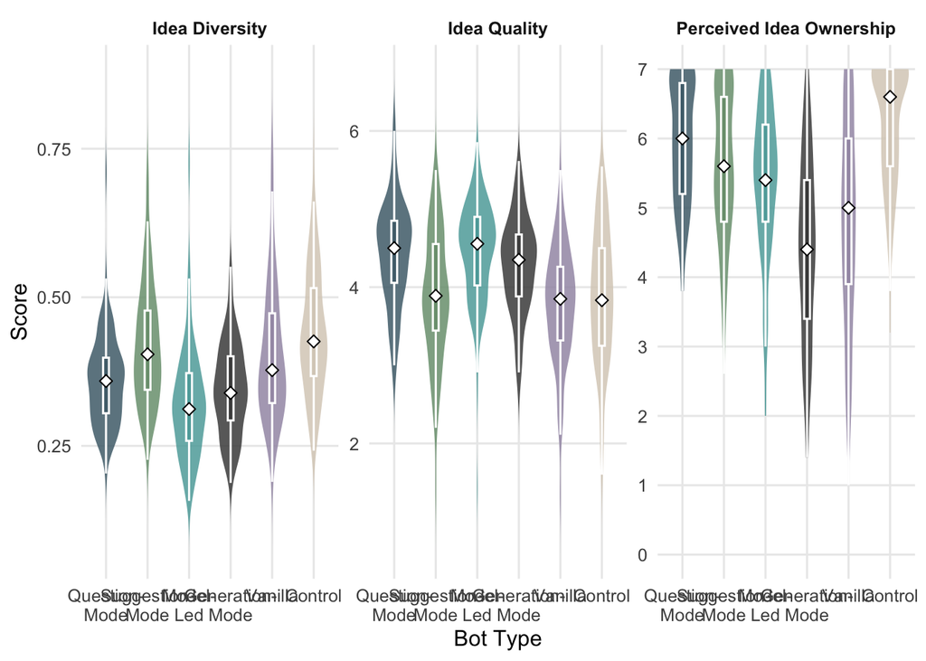

```r
# --- Define key variables for plots ---
idea_quality_col <- "Idea_Quality"
refined_div_col <- "refined_div_condition"

# Ensure numeric format
data_full <- data_full %>%
  mutate(
    !!idea_quality_col := as.numeric(!!sym(idea_quality_col)),
    !!refined_div_col := as.numeric(!!sym(refined_div_col)),
    Perceived_Ownership = as.numeric(Perceived_Ownership)
  )

# --- Conditions and approved colors ---
# Standardized order for all graphics: Question-mode, Suggestion-mode, Model-led, Generation, Vanilla, Control
desired_levels <- c("feedback", "suggestion", "improvement", "generation", "vanilla", "control")
present_levels <- desired_levels[desired_levels %in% unique(as.character(data_full$bot_type))]

data_full <- data_full %>%
  mutate(bot_type = factor(as.character(bot_type), levels = present_levels))


# Pretty labels for bot types (single-line for non-boxplot graphics)
# Note: Using the global label_map defined earlier, no need to redefine



# --- Long data for the three DVs ---
dv_vars <- c(refined_div_col, idea_quality_col, "Perceived_Ownership")
dv_labels <- setNames(
  c("Idea Diversity", "Idea Quality", "Perceived Idea Ownership"),
  dv_vars
)

plot_data <- data_full %>%
  select(bot_type, all_of(dv_vars)) %>%
  pivot_longer(cols = all_of(dv_vars), names_to = "dv", values_to = "score") %>%
  filter(!is.na(bot_type), !is.na(score)) %>%
  mutate(
    # Limit Perceived Ownership to 0-7 range
    score = ifelse(dv == "Perceived_Ownership", pmin(pmax(score, 0), 7), score),
    dv = factor(dv, levels = dv_vars, labels = dv_labels[dv_vars])
  )

# --- Violin plot (facetted) ---
p_violin <- ggplot(plot_data, aes(x = bot_type, y = score, fill = bot_type)) +
  geom_violin(data = filter(plot_data, dv != "Perceived Idea Ownership"),
              trim = FALSE, alpha = 0.85, color = NA) +
  geom_violin(data = filter(plot_data, dv == "Perceived Idea Ownership"),
              trim = TRUE, alpha = 0.85, color = NA) +
  geom_boxplot(width = 0.14, outlier.shape = NA, color = "white", alpha = 0.95) +
  stat_summary(fun = median, geom = "point", shape = 23, size = 2.2, fill = "white") +
  facet_wrap(~ dv, scales = "free_y", ncol = 3) +
  ggh4x::facetted_pos_scales(
    y = list(
      dv == "Perceived Idea Ownership" ~ scale_y_continuous(limits = c(0, 7), breaks = seq(0, 7, 1))
    )
  ) +
  scale_x_discrete(limits = present_levels, labels = boxplot_label_map[present_levels]) +
  scale_fill_manual(values = bot_colors[present_levels],
                    breaks = present_levels,
                    labels = boxplot_label_map[present_levels],
                    limits = present_levels) +
  labs(x = "Bot Type", y = "Score") +
  guides(fill = "none") +
  theme_minimal(base_size = 12) +
  theme(panel.grid.minor = element_blank(),
        strip.text = element_text(face = "bold"))

print(p_violin)
```

```r
# Save
dir.create(here::here("Analysis", "Figures"), showWarnings = FALSE, recursive = TRUE)
ggsave(
  filename = here::here("Analysis", "Figures", "violin_refinedSim_ideaQuality_ownership_by_condition.png"),
  plot = p_violin, width = 12, height = 4.5, dpi = 300, bg = "white"
)
# Also save as PDF for Overleaf (vector graphics)
ggsave(
  filename = here::here("Analysis", "Figures", "violin_refinedSim_ideaQuality_ownership_by_condition.pdf"),
  plot = p_violin, width = 12, height = 4.5, device = "pdf", bg = "white", useDingbats = FALSE
)
```

# Violin Plot: Purchase Intent by Condition

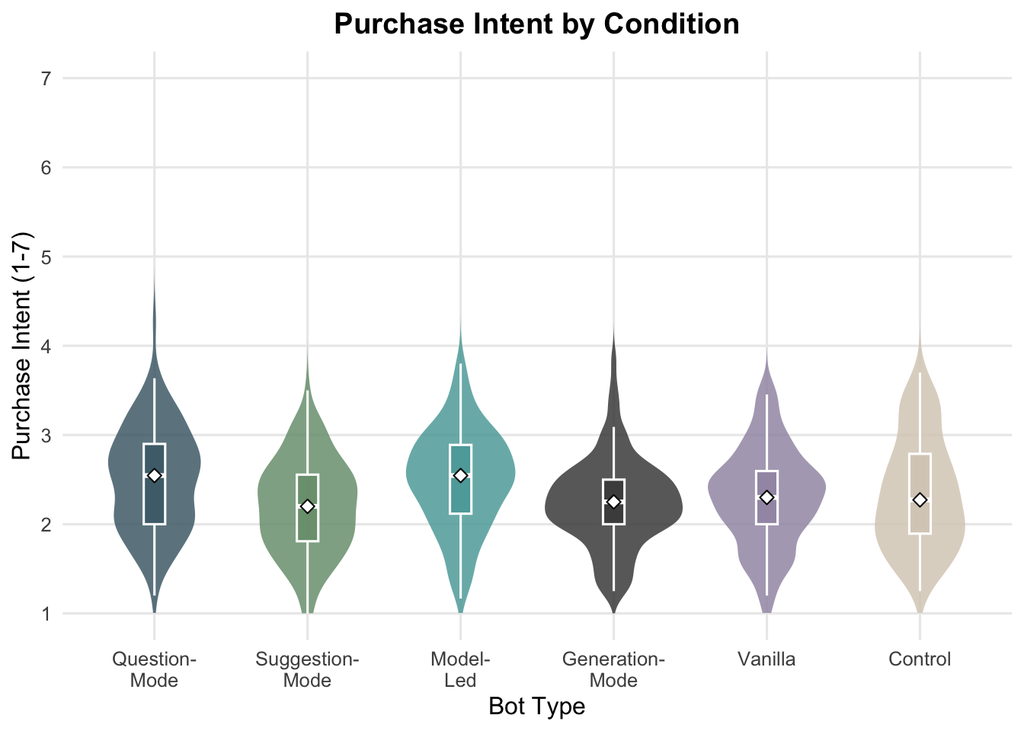

```r
# Prepare data for purchase intent violin plot
purchase_data <- data_full %>%
  dplyr::select(bot_type, purchase_intent_mean) %>%
  dplyr::filter(!is.na(bot_type), !is.na(purchase_intent_mean))

# Create violin plot for purchase intent
p_purchase_violin <- ggplot(purchase_data, aes(x = bot_type, y = purchase_intent_mean, fill = bot_type)) +
  geom_violin(trim = FALSE, alpha = 0.85, color = NA) +
  geom_boxplot(width = 0.14, outlier.shape = NA, color = "white", alpha = 0.95) +
  stat_summary(fun = median, geom = "point", shape = 23, size = 2.2, fill = "white") +
  scale_x_discrete(limits = present_levels, labels = boxplot_label_map[present_levels]) +
  scale_fill_manual(values = bot_colors[present_levels],
                    breaks = present_levels,
                    labels = boxplot_label_map[present_levels],
                    limits = present_levels) +
  labs(x = "Bot Type", y = "Purchase Intent (1-7)", title = "Purchase Intent by Condition") +
  scale_y_continuous(limits = c(1, 7), breaks = seq(1, 7, 1)) +
  guides(fill = "none") +
  theme_minimal(base_size = 12) +
  theme(
    panel.grid.minor = element_blank(),
    plot.title = element_text(hjust = 0.5, face = "bold")
  )

print(p_purchase_violin)
```

```r
# Save outputs
dir.create(here::here("Analysis", "Figures"), showWarnings = FALSE, recursive = TRUE)

# Save as PNG
ggsave(
  filename = here::here("Analysis", "Figures", "violin_purchase_intent_by_condition.png"),
  plot = p_purchase_violin, width = 8, height = 5, dpi = 300, bg = "white"
)
# Save as PDF for publication
ggsave(
  filename = here::here("Analysis", "Figures", "violin_purchase_intent_by_condition.pdf"),
  plot = p_purchase_violin, width = 8, height = 5, device = "pdf", bg = "white", useDingbats = FALSE
)
# Print summary statistics by condition
cat("\n=== Purchase Intent Summary by Condition ===\n")
```

```
##
## === Purchase Intent Summary by Condition ===
```

```r
purchase_summary <- purchase_data %>%
  group_by(bot_type) %>%
  summarise(
    n = n(),
    mean = mean(purchase_intent_mean, na.rm = TRUE),
    sd = sd(purchase_intent_mean, na.rm = TRUE),
    median = median(purchase_intent_mean, na.rm = TRUE),
    min = min(purchase_intent_mean, na.rm = TRUE),
    max = max(purchase_intent_mean, na.rm = TRUE),
    .groups = "drop"
  )
print(purchase_summary)
```

```
## # A tibble: 6 × 7
##   bot_type        n  mean    sd median   min   max
##   <fct>       <int> <dbl> <dbl>  <dbl> <dbl> <dbl>
## 1 feedback       97  2.51 0.579   2.55  1.2   4.27
## 2 suggestion     99  2.20 0.526   2.2   1     3.5
## 3 improvement   151  2.50 0.555   2.55  1.17  3.8
## 4 generation     99  2.24 0.493   2.25  1.25  3.85
## 5 vanilla        95  2.30 0.545   2.3   1     3.5
## 6 control        99  2.34 0.618   2.27  1.25  3.7
```

# Mean Differences Plot: Purchase Intent with Confidence Intervals

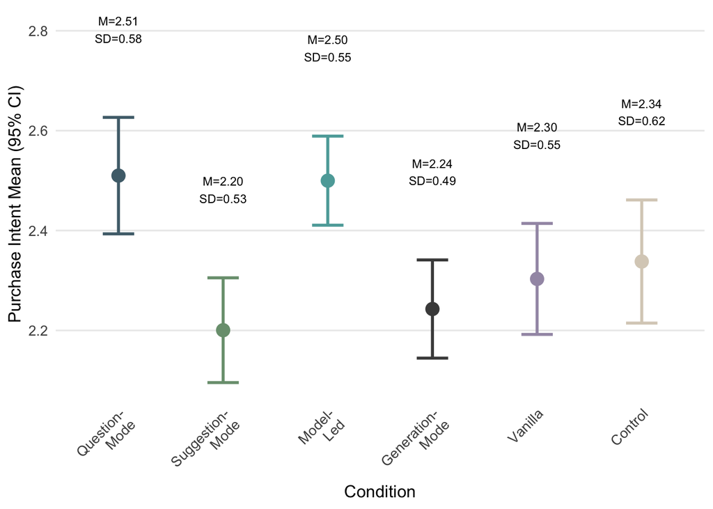

```r
# Calculate means and 95% CIs for purchase intent
purchase_mean_data <- data_full %>%
  filter(!is.na(bot_type), !is.na(purchase_intent_mean)) %>%
  group_by(bot_type) %>%
  summarise(
    n = n(),
    mean = mean(purchase_intent_mean, na.rm = TRUE),
    sd = sd(purchase_intent_mean, na.rm = TRUE),
    se = sd / sqrt(n),
    ci_lower = mean - qt(0.975, df = n - 1) * se,
    ci_upper = mean + qt(0.975, df = n - 1) * se,
    .groups = "drop"
  )

# Create point plot with error bars (no connecting lines)
p_purchase_means <- ggplot(purchase_mean_data, aes(x = bot_type, y = mean, color = bot_type)) +
  geom_point(size = 4) +
  geom_errorbar(aes(ymin = ci_lower, ymax = ci_upper),
                width = 0.3, size = 1) +
  geom_text(aes(
    label = sprintf("M=%.2f\nSD=%.2f", mean, sd),
    y = ci_upper + 0.15
  ),
  color = "black", size = 3, vjust = 0
  ) +
  scale_x_discrete(limits = present_levels, labels = boxplot_label_map[present_levels]) +
  scale_color_manual(values = bot_colors[present_levels],
                     breaks = present_levels,
                     labels = boxplot_label_map[present_levels],
                     limits = present_levels) +
  labs(
    x = "Condition",
    y = "Purchase Intent Mean (95% CI)") +
  scale_y_continuous(expand = expansion(mult = c(0.05, 0.1))) +
  guides(color = "none") +
  theme_minimal(base_size = 12) +
  theme(
    panel.grid.minor = element_blank(),
    panel.grid.major.x = element_blank(),
    plot.title = element_text(hjust = 0.5, face = "bold", size = 13),
    axis.text.x = element_text(angle = 45, hjust = 1, size = 10),
    axis.text.y = element_text(size = 10)
  )
print(p_purchase_means)
```

```r
# Save the plot
ggsave(
  filename = here::here("Analysis", "Figures", "purchase_intent_means_with_CI.png"),
  plot = p_purchase_means, width = 8, height = 5, dpi = 300, bg = "white"
)

ggsave(
  filename = here::here("Analysis", "Figures", "purchase_intent_means_with_CI.pdf"),
  plot = p_purchase_means, width = 8, height = 5, device = "pdf", bg = "white", useDingbats = FALSE
)

# Print summary table
cat("\n=== Purchase Intent: Means and 95% CIs by Condition ===\n")
```

```
##
## === Purchase Intent: Means and 95% CIs by Condition ===
```

```r
purchase_mean_summary <- purchase_mean_data %>%
  mutate(
    mean_ci = sprintf("%.2f [%.2f, %.2f]", mean, ci_lower, ci_upper)
  ) %>%
  select(bot_type, n, mean, sd, mean_ci)

print(purchase_mean_summary)
```

```
## # A tibble: 6 × 5
##   bot_type        n  mean    sd mean_ci
##   <fct>       <int> <dbl> <dbl> <chr>
## 1 feedback       97  2.51 0.579 2.51 [2.39, 2.63]
## 2 suggestion     99  2.20 0.526 2.20 [2.10, 2.31]
## 3 improvement   151  2.50 0.555 2.50 [2.41, 2.59]
## 4 generation     99  2.24 0.493 2.24 [2.14, 2.34]
## 5 vanilla        95  2.30 0.545 2.30 [2.19, 2.41]
## 6 control        99  2.34 0.618 2.34 [2.21, 2.46]
```

## ANOVA: Purchase Intent Differences Across Conditions

```r
# Prepare data for ANOVA
purchase_anova_data <- data_full %>%
  filter(!is.na(bot_type), !is.na(purchase_intent_mean)) %>%
  mutate(bot_type = factor(bot_type,
                           levels = c("feedback", "suggestion", "improvement", "generation", "vanilla", "control")))

# Fit ANOVA model
purchase_anova_model <- aov(purchase_intent_mean ~ bot_type, data = purchase_anova_data)

purchase_emm <- emmeans(purchase_anova_model, specs = ~ bot_type)

purchase_pairs_holm <- pairs(purchase_emm, adjust = "holm")

purchase_pairs_df <- as.data.frame(purchase_pairs_holm) %>%
  mutate(
    comparison = as.character(contrast),
    p_adj_holm = p.value,
    significant = ifelse(p.value < 0.05, "*", ""),
    significant = ifelse(p.value < 0.01, "**", significant),
    significant = ifelse(p.value < 0.001, "***", significant)
  ) %>%
  select(comparison, estimate, SE, df, t.ratio, p_adj_holm, significant)

n_sig <- sum(purchase_pairs_df$p_adj_holm < 0.05)
purchase_pairs_df
```

```
##                  comparison    estimate         SE  df    t.ratio  p_adj_holm
## 1     feedback - suggestion  0.30951223 0.07914728 634  3.9105858 0.001428039
## 2    feedback - improvement  0.01011435 0.07208799 634  0.1403056 1.000000000
## 3     feedback - generation  0.26709659 0.07914728 634  3.3746781 0.009409231
## 4        feedback - vanilla  0.20683936 0.07996766 634  2.5865378 0.099162295
## 5        feedback - control  0.17199254 0.07914728 634  2.1730694 0.241157113
## 6  suggestion - improvement -0.29939788 0.07164326 634 -4.1790095 0.000500853
## 7   suggestion - generation -0.04241564 0.07874243 634 -0.5386630 1.000000000
## 8      suggestion - vanilla -0.10267286 0.07956698 634 -1.2903953 1.000000000
## 9      suggestion - control -0.13751969 0.07874243 634 -1.7464496 0.568519995
## 10 improvement - generation  0.25698224 0.07164326 634  3.5869701 0.004684095
## 11    improvement - vanilla  0.19672501 0.07254854 634  2.7116328 0.075644224
## 12    improvement - control  0.16187818 0.07164326 634  2.2595032 0.217716921
## 13     generation - vanilla -0.06025723 0.07956698 634 -0.7573145 1.000000000
## 14     generation - control -0.09510405 0.07874243 634 -1.2077866 1.000000000
## 15        vanilla - control -0.03484683 0.07956698 634 -0.4379559 1.000000000
##    significant
## 1           **
## 2
## 3           **
## 4
## 5
## 6          ***
## 7
## 8
## 9
## 10          **
## 11
## 12
## 13
## 14
## 15
```

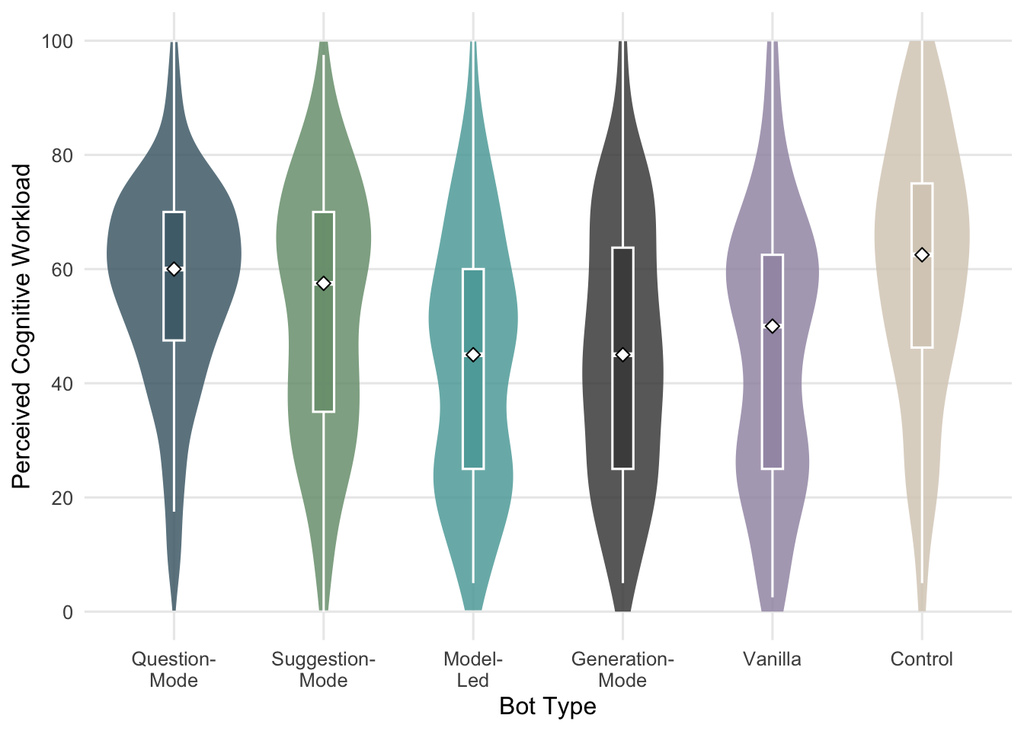

```r
# Violin plot for NASA-TLX composite measure: Perceived Cognitive Workload

# Custom bot order for TLX violin: Question-mode, Suggestion-mode, Model-led, Generation, Vanilla, Control
desired_levels_tlx <- c("feedback", "suggestion", "improvement", "generation", "vanilla", "control")
present_levels_tlx <- desired_levels_tlx[desired_levels_tlx %in% unique(as.character(data_full$bot_type))]

# Prepare data for composite NASA-TLX measure
tlx_data <- data_full %>%
  dplyr::select(bot_type, NASA_TLX) %>%
  dplyr::filter(!is.na(bot_type), !is.na(NASA_TLX)) %>%
  dplyr::mutate(bot_type = factor(as.character(bot_type), levels = present_levels_tlx))

p_tlx_violin <- ggplot2::ggplot(tlx_data, ggplot2::aes(x = bot_type, y = NASA_TLX, fill = bot_type)) +
  ggplot2::geom_violin(trim = FALSE, alpha = 0.85, color = NA) +
  ggplot2::geom_boxplot(width = 0.14, outlier.shape = NA, color = "white", alpha = 0.95) +
  ggplot2::stat_summary(fun = median, geom = "point", shape = 23, size = 2.2, fill = "white") +
  ggplot2::scale_x_discrete(limits = present_levels_tlx, labels = boxplot_label_map[present_levels_tlx]) +
  ggplot2::scale_fill_manual(values = bot_colors[present_levels_tlx],
                             breaks = present_levels_tlx,
                             labels = boxplot_label_map[present_levels_tlx],
                             limits = present_levels_tlx) +
  ggplot2::labs(x = "Bot Type", y = "Perceived Cognitive Workload") +
  ggplot2::scale_y_continuous(limits = c(0, 100), breaks = seq(0, 100, 20)) +
  ggplot2::guides(fill = "none") +
  ggplot2::theme_minimal(base_size = 12) +
  ggplot2::theme(panel.grid.minor = ggplot2::element_blank())

print(p_tlx_violin)
```

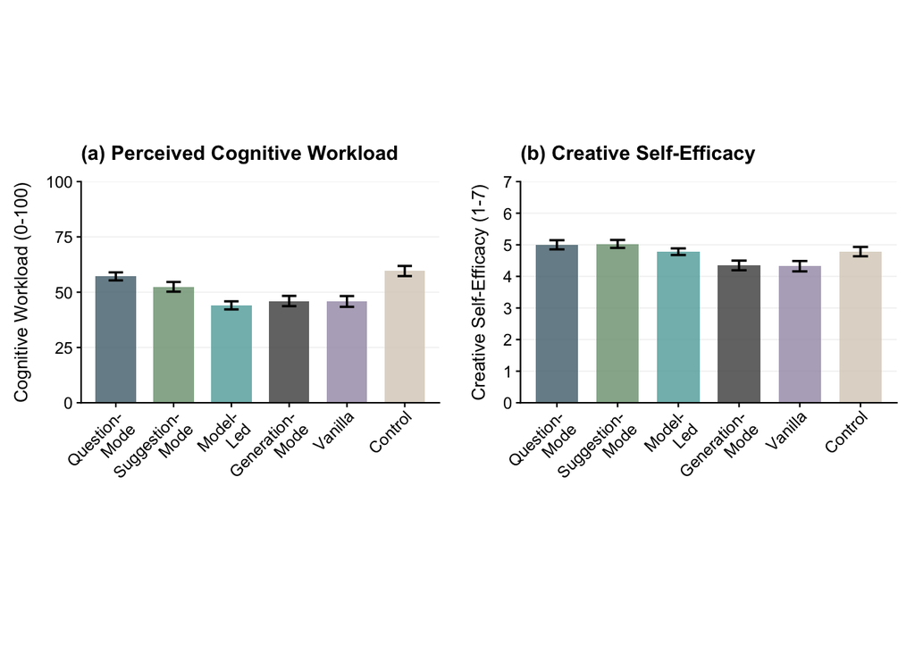

```r
# Create bar charts for cognitive workload and creative self-efficacy
# Prepare data for bar charts - calculate means and standard errors
bar_data <- data_full %>%
  dplyr::filter(!is.na(bot_type)) %>%
  dplyr::mutate(bot_type = factor(as.character(bot_type), levels = present_levels_tlx)) %>%
  dplyr::group_by(bot_type) %>%
  dplyr::summarise(
    NASA_TLX_mean = mean(NASA_TLX, na.rm = TRUE),
    NASA_TLX_se = sd(NASA_TLX, na.rm = TRUE) / sqrt(n()),
    Creative_Self_Efficacy_mean = mean(Creative_Self_Efficacy, na.rm = TRUE),
    Creative_Self_Efficacy_se = sd(Creative_Self_Efficacy, na.rm = TRUE) / sqrt(n()),
    n = n(),
    .groups = 'drop'
  ) %>%
  dplyr::filter(!is.na(bot_type))


# Create cognitive workload bar chart (ACM/CHI publication style)
p_tlx_bar <- ggplot2::ggplot(bar_data, ggplot2::aes(x = bot_type, y = NASA_TLX_mean, fill = bot_type)) +
  ggplot2::geom_col(alpha = 0.8, color = NA, width = 0.7) +
  ggplot2::geom_errorbar(ggplot2::aes(ymin = pmax(0, NASA_TLX_mean - NASA_TLX_se),
                                      ymax = pmin(100, NASA_TLX_mean + NASA_TLX_se)),
                         width = 0.25, size = 0.6, color = "black") +
  ggplot2::scale_x_discrete(limits = present_levels_tlx, labels = boxplot_label_map[present_levels_tlx]) +
  ggplot2::scale_fill_manual(values = bot_colors[present_levels_tlx],
                             breaks = present_levels_tlx,
                             labels = boxplot_label_map[present_levels_tlx],
                             limits = present_levels_tlx) +
  ggplot2::labs(x = "", y = "Cognitive Workload (0-100)", title = "(a) Perceived Cognitive Workload") +
  ggplot2::scale_y_continuous(limits = c(0, 100), breaks = seq(0, 100, 25), expand = c(0, 0)) +
  ggplot2::guides(fill = "none") +
  ggplot2::theme_classic(base_size = 10) +
  ggplot2::theme(
    plot.title = ggplot2::element_text(hjust = 0, size = 11, face = "bold", margin = ggplot2::margin(b = 10)),
    axis.title.y = ggplot2::element_text(size = 10, margin = ggplot2::margin(r = 8)),
    axis.text.x = ggplot2::element_text(size = 9, angle = 45, hjust = 1, margin = ggplot2::margin(t = 1)),
    axis.text.y = ggplot2::element_text(size = 9),
    axis.line = ggplot2::element_line(color = "black", size = 0.4),
    axis.ticks = ggplot2::element_line(color = "black", size = 0.4),
    panel.background = ggplot2::element_rect(fill = "white", color = NA),
    plot.background = ggplot2::element_rect(fill = "white", color = NA),
    panel.grid.major.y = ggplot2::element_line(color = "gray95", size = 0.3),
    panel.grid.major.x = ggplot2::element_blank(),
    plot.margin = ggplot2::margin(8, 10, 4, 8)
  )
# Create creative self-efficacy bar chart (ACM/CHI publication style)
p_cse_bar <- ggplot2::ggplot(bar_data, ggplot2::aes(x = bot_type, y = Creative_Self_Efficacy_mean, fill = bot_type)) +
  ggplot2::geom_col(alpha = 0.8, color = NA, width = 0.7) +
  ggplot2::geom_errorbar(ggplot2::aes(ymin = pmax(0, Creative_Self_Efficacy_mean - Creative_Self_Efficacy_se),
                                      ymax = pmin(7, Creative_Self_Efficacy_mean + Creative_Self_Efficacy_se)),
                         width = 0.25, size = 0.6, color = "black") +
  ggplot2::scale_x_discrete(limits = present_levels_tlx, labels = boxplot_label_map[present_levels_tlx]) +
  ggplot2::scale_fill_manual(values = bot_colors[present_levels_tlx],
                             breaks = present_levels_tlx,
                             labels = boxplot_label_map[present_levels_tlx],
                             limits = present_levels_tlx) +
  ggplot2::labs(x = "", y = "Creative Self-Efficacy (1-7)", title = "(b) Creative Self-Efficacy") +
  ggplot2::scale_y_continuous(limits = c(0, 7), breaks = seq(0, 7, 1), expand = c(0, 0)) +
  ggplot2::guides(fill = "none") +
  ggplot2::theme_classic(base_size = 10) +
  ggplot2::theme(
    plot.title = ggplot2::element_text(hjust = 0, size = 11, face = "bold", margin = ggplot2::margin(b = 10)),
    axis.title.y = ggplot2::element_text(size = 10, margin = ggplot2::margin(r = 8)),
    axis.text.x = ggplot2::element_text(size = 9, angle = 45, hjust = 1, margin = ggplot2::margin(t = 1)),
    axis.text.y = ggplot2::element_text(size = 9),
    axis.line = ggplot2::element_line(color = "black", size = 0.4),
    axis.ticks = ggplot2::element_line(color = "black", size = 0.4),
    panel.background = ggplot2::element_rect(fill = "white", color = NA),
    plot.background = ggplot2::element_rect(fill = "white", color = NA),
    panel.grid.major.y = ggplot2::element_line(color = "gray95", size = 0.3),
    panel.grid.major.x = ggplot2::element_blank(),
    plot.margin = ggplot2::margin(8, 10, 4, 8)
  )

# Combine bar charts side by side with minimal spacing
combined_bar_plot <- gridExtra::grid.arrange(
  p_tlx_bar, p_cse_bar,
  ncol = 2,
  heights = grid::unit(3, "in"),
  widths = grid::unit(c(3.5, 3.5), "in")
)
```

```r
print(combined_bar_plot)
```

```r
# Save outputs
dir.create(here::here("Analysis", "Figures"), showWarnings = FALSE, recursive = TRUE)

# Save violin plots
ggplot2::ggsave(
  filename = here::here("Analysis", "Figures", "violin_cognitive_workload_by_condition.png"),
  plot = p_tlx_violin, width = 7, height = 4.5, dpi = 300, bg = "white"
)
ggplot2::ggsave(
  filename = here::here("Analysis", "Figures", "violin_cognitive_workload_by_condition.pdf"),
  plot = p_tlx_violin, width = 7, height = 4.5, device = "pdf", bg = "white", useDingbats = FALSE
)
# Save bar charts (ACM/CHI publication quality)
ggplot2::ggsave(
  filename = here::here("Analysis", "Figures", "bar_cognitive_workload_creativeSE_by_condition.png"),
  plot = combined_bar_plot, width = 7, height = 3.5, dpi = 600, bg = "white", units = "in"
)
ggplot2::ggsave(
  filename = here::here("Analysis", "Figures", "bar_cognitive_workload_creativeSE_by_condition.pdf"),
  plot = combined_bar_plot, width = 7, height = 3.5, device = "pdf", bg = "white",
  useDingbats = FALSE, units = "in"
)

# Save individual charts for single-column figures if needed
ggplot2::ggsave(
  filename = here::here("Analysis", "Figures", "bar_cognitive_workload_publication.pdf"),
  plot = p_tlx_bar, width = 3.5, height = 3, device = "pdf", bg = "white",
  useDingbats = FALSE, units = "in"
)
ggplot2::ggsave(
  filename = here::here("Analysis", "Figures", "bar_creative_self_efficacy_publication.pdf"),
  plot = p_cse_bar, width = 3.5, height = 3, device = "pdf", bg = "white",
  useDingbats = FALSE, units = "in"
)
```

# ROBUSTNESS CHECKS

This section presents robustness checks for the three main dependent variables: Idea Quality, Idea Diversity, and Perceived Ownership. These checks assess whether the main findings are robust to alternative modeling approaches and distributional assumptions.

### 1.2 Ordinal Mixed Model (CLMM)

As an alternative robustness check for the ordinal quality ratings, we use a cumulative link mixed model (CLMM). This approach treats quality ratings as ordered categories rather than continuous variables, while still accounting for the crossed random effects of `idea_id` and `evaluator_study_id`.

```r
# Inspect distribution of idea_quality
summary(data_evaluators_with_bottype$idea_quality)
```

```
##    Min. 1st Qu.  Median    Mean 3rd Qu.    Max.
##    1.00    3.00    4.00    4.15    5.00    7.00
```

```r
table(data_evaluators_with_bottype$idea_quality)
```

```
##
##   1 1.5   2 2.5   3 3.5   4 4.5   5 5.5   6 6.5   7
## 234 208 320 416 531 707 797 746 785 611 476 234 235
```

```r
# Convert idea_quality to ordered factor (without binning)
data_evaluators_ordinal <- data_evaluators_with_bottype %>%
  mutate(quality_ord = factor(idea_quality, ordered = TRUE)) %>%
  filter(!is.na(quality_ord))

# Fit ordinal mixed model
clmm_quality <- clmm(
  quality_ord ~ bot_type + (1 | idea_id) + (1 | evaluator_study_id),
  data = data_evaluators_ordinal,
  link = "logit"
)
summary(clmm_quality)
```

```
## Cumulative Link Mixed Model fitted with the Laplace approximation
##
## formula: quality_ord ~ bot_type + (1 | idea_id) + (1 | evaluator_study_id)
## data:    data_evaluators_ordinal
##
##  link  threshold nobs logLik    AIC      niter       max.grad cond.H
##  logit flexible  6300 -14611.23 29260.46 3875(26059) 2.32e-02 1.4e+03
##
## Random effects:
##  Groups             Name        Variance Std.Dev.
##  idea_id            (Intercept) 0.7914   0.8896
##  evaluator_study_id (Intercept) 1.1847   1.0884
## Number of groups:  idea_id 640,  evaluator_study_id 258
##
## Coefficients:
##                      Estimate Std. Error z value Pr(>|z|)
## bot_typesuggestion  -0.817535   0.151932  -5.381 7.41e-08 ***
## bot_typeimprovement  0.004976   0.137971   0.036    0.971
## bot_typegeneration  -0.184279   0.151193  -1.219    0.223
## bot_typevanilla     -1.012360   0.153864  -6.580 4.72e-11 ***
## bot_typecontrol     -0.826511   0.151921  -5.440 5.32e-08 ***
## ---
## Signif. codes:  0 '***' 0.001 '**' 0.01 '*' 0.05 '.' 0.1 ' ' 1
##
## Threshold coefficients:
##       Estimate Std. Error z value
## 1|1.5  -4.6143     0.1496 -30.842
## 1.5|2  -3.8097     0.1405 -27.109
## 2|2.5  -3.0487     0.1353 -22.536
## 2.5|3  -2.3790     0.1324 -17.969
## 3|3.5  -1.7306     0.1306 -13.252
## 3.5|4  -1.0207     0.1294  -7.889
## 4|4.5  -0.3064     0.1288  -2.379
## 4.5|5   0.3538     0.1289   2.746
## 5|5.5   1.1243     0.1296   8.673
## 5.5|6   1.8963     0.1314  14.427
## 6|6.5   2.8336     0.1361  20.818
## 6.5|7   3.6744     0.1448  25.383
```

```r
# Likelihood ratio test for bot_type effect
clmm_null <- clmm(
  quality_ord ~ 1 + (1 | idea_id) + (1 | evaluator_study_id),
  data = data_evaluators_ordinal,
  link = "logit"
)

anova(clmm_null, clmm_quality)
```

```
## Likelihood ratio tests of cumulative link models:
##
##              formula:
## clmm_null    quality_ord ~ 1 + (1 | idea_id) + (1 | evaluator_study_id)
## clmm_quality quality_ord ~ bot_type + (1 | idea_id) + (1 | evaluator_study_id)
##              link: threshold:
## clmm_null    logit flexible
## clmm_quality logit flexible
##
##              no.par   AIC logLik LR.stat df Pr(>Chisq)
## clmm_null        14 29345 -14659
## clmm_quality     19 29260 -14611  94.857  5  < 2.2e-16 ***
## ---
## Signif. codes:  0 '***' 0.001 '**' 0.01 '*' 0.05 '.' 0.1 ' ' 1
```

```r
# Post hoc tests for H1a–H1e on CLMM
# Use the same hypothesis contrasts as in the primary mixed model

# Estimated marginal means for bot_type from the CLMM
clmm_quality_emm <- emmeans(clmm_quality, specs = ~ bot_type, mode = "latent")

# Define contrasts (order of bot_type levels must match the factor in the data)
contrast_list_clmm <- list(
  H1a = c(1,  0,  0,  0, 0, -1),   # feedback vs control
  H1b = c(0,  1,  0,  0, 0, -1),   # suggestion vs control
  H1c = c(0,  0,  1,  0, 0, -1),   # improvement one-shot vs control
  H1d = c(0,  0,  0,  1, 0, -1),   # improvement iterative vs control
  H1e = c(0,  0,  0,  0, 1, -1)    # vanilla vs control
)

# Holm-adjusted, one-sided tests
contrast_adjusted_clmm <- contrast(
  clmm_quality_emm,
  method = contrast_list_clmm,
  adjust = "holm",
  infer = TRUE,
  side = ">"
)
contrast_adjusted_clmm
```

```
##  contrast estimate    SE  df asymp.LCL asymp.UCL z.ratio p.value
##  H1a       0.82651 0.152 Inf     0.473       Inf   5.440  <.0001
##  H1b       0.00898 0.151 Inf    -0.342       Inf   0.059  0.9526
##  H1c       0.83149 0.137 Inf     0.512       Inf   6.049  <.0001
##  H1d       0.64223 0.151 Inf     0.292       Inf   4.261  <.0001
##  H1e      -0.18585 0.153 Inf    -0.541       Inf  -1.217  0.9526
##
## Confidence level used: 0.95
## Conf-level adjustment: bonferroni method for 5 estimates
## P value adjustment: holm method for 5 tests
## P values are right-tailed
```

## 2. Idea Diversity Robustness Checks

### 2.1 HC3 Heteroscedasticity-Robust Standard Errors

We re-estimate the diversity model with heteroscedasticity-consistent (HC3) standard errors to ensure our inferences are robust to potential violations of homoscedasticity.

```r
summary(DIV_model)
```

```
##
## Call:
## lm(formula = refined_div_condition ~ bot_type, data = data_full)
##
## Residuals:
##      Min       1Q   Median       3Q      Max
## -0.21558 -0.06871 -0.00944  0.05603  0.41382
##
## Coefficients:
##                     Estimate Std. Error t value Pr(>|t|)
## (Intercept)          0.35884    0.00969  37.031  < 2e-16 ***
## bot_typesuggestion   0.06142    0.01363   4.504 7.92e-06 ***
## bot_typeimprovement -0.03733    0.01242  -3.006 0.002754 **
## bot_typegeneration  -0.01378    0.01363  -1.011 0.312495
## bot_typevanilla      0.04618    0.01378   3.352 0.000849 ***
## bot_typecontrol      0.08126    0.01363   5.960 4.19e-09 ***
## ---
## Signif. codes:  0 '***' 0.001 '**' 0.01 '*' 0.05 '.' 0.1 ' ' 1
##
## Residual standard error: 0.09544 on 634 degrees of freedom
## Multiple R-squared:  0.1782, Adjusted R-squared:  0.1717
## F-statistic: 27.49 on 5 and 634 DF,  p-value: < 2.2e-16
```

```r
robust_div <- coeftest(DIV_model, vcov = vcovHC(DIV_model, type = "HC3"))
robust_div
```

```
##
## t test of coefficients:
##
##                       Estimate Std. Error t value  Pr(>|t|)
## (Intercept)          0.3588348  0.0077402 46.3598 < 2.2e-16 ***
## bot_typesuggestion   0.0614158  0.0128037  4.7967 2.012e-06 ***
## bot_typeimprovement -0.0373264  0.0109063 -3.4225 0.0006605 ***
## bot_typegeneration  -0.0137819  0.0110185 -1.2508 0.2114684
## bot_typevanilla      0.0461795  0.0141601  3.2612 0.0011687 **
## bot_typecontrol      0.0812612  0.0130582  6.2230 8.866e-10 ***
## ---
## Signif. codes:  0 '***' 0.001 '**' 0.01 '*' 0.05 '.' 0.1 ' ' 1
```

```r
# Compare standard errors
comparison_div <- data.frame(
  Coefficient = names(coef(DIV_model)),
  Original_SE = summary(DIV_model)$coefficients[, "Std. Error"],
  Robust_SE = robust_div[, "Std. Error"],
  SE_Ratio = robust_div[, "Std. Error"] / summary(DIV_model)$coefficients[, "Std. Error"]
)
comparison_div
```

```
##                             Coefficient Original_SE   Robust_SE  SE_Ratio
## (Intercept)                 (Intercept) 0.009690192 0.007740206 0.7987670
## bot_typesuggestion   bot_typesuggestion 0.013634613 0.012803651 0.9390550
## bot_typeimprovement bot_typeimprovement 0.012418517 0.010906262 0.8782258
## bot_typegeneration   bot_typegeneration 0.013634613 0.011018484 0.8081259
## bot_typevanilla         bot_typevanilla 0.013775938 0.014160070 1.0278843
## bot_typecontrol         bot_typecontrol 0.013634613 0.013058173 0.9577223
```

### Robustness Check with Logit-Transformed Diversity

```r
# Model already created in assumption tests section above
summary(DIV_model_logit)
```

```
##
## Call:
## lm(formula = refined_div_condition_logit ~ bot_type, data = data_full)
##
## Residuals:
##      Min       1Q   Median       3Q      Max
## -1.05440 -0.29644 -0.02348  0.25234  1.79664
##
## Coefficients:
##                     Estimate Std. Error t value Pr(>|t|)
## (Intercept)         -0.59335    0.04236 -14.009  < 2e-16 ***
## bot_typesuggestion   0.26101    0.05960   4.379 1.39e-05 ***
## bot_typeimprovement -0.18148    0.05428  -3.343 0.000877 ***
## bot_typegeneration  -0.06593    0.05960  -1.106 0.269064
## bot_typevanilla      0.19405    0.06022   3.223 0.001335 **
## bot_typecontrol      0.34356    0.05960   5.765 1.28e-08 ***
## ---
## Signif. codes:  0 '***' 0.001 '**' 0.01 '*' 0.05 '.' 0.1 ' ' 1
##
## Residual standard error: 0.4172 on 634 degrees of freedom
## Multiple R-squared:  0.1807, Adjusted R-squared:  0.1743
## F-statistic: 27.97 on 5 and 634 DF,  p-value: < 2.2e-16
```

```r
anova(DIV_model_logit)
```

```
## Analysis of Variance Table
##
## Response: refined_div_condition_logit
##            Df  Sum Sq Mean Sq F value    Pr(>F)
## bot_type    5  24.336  4.8672  27.969 < 2.2e-16 ***
## Residuals 634 110.331  0.1740
## ---
## Signif. codes:  0 '***' 0.001 '**' 0.01 '*' 0.05 '.' 0.1 ' ' 1
```

```r
# Estimate marginal means
SIM_emm_logit <- emmeans(DIV_model_logit, specs = ~ bot_type)

# Define the same contrasts for H2 & H3
contrast_list <- list(
  H2a = c(1, 0, -1,  0,  0, 0), #feedback vs. improvement one-shot
  H2b = c(1, 0,  0, -1,  0, 0), #feedback vs. improvement iterative
  H2c = c(1, 0,  0,  0, -1, 0), #feedback vs. vanilla
  H3a = c(0, 1, -1,  0,  0, 0), #suggestion vs. improvement
  H3b = c(0, 1,  0, -1,  0, 0), #suggestion vs. iterative
  H3c = c(0, 1,  0,  0, -1, 0) #suggestion vs. vanilla
)

# Get Holm-adjusted p-values
contrast_adjusted_logit <- contrast(SIM_emm_logit, method = contrast_list, adjust = "holm", infer = TRUE, side = ">")
contrast_adjusted_logit
```

```
##  contrast estimate     SE  df lower.CL upper.CL t.ratio p.value
##  H2a        0.1815 0.0543 634   0.0512      Inf   3.343  0.0018
##  H2b        0.0659 0.0596 634  -0.0771      Inf   1.106  0.3963
##  H2c       -0.1941 0.0602 634  -0.3386      Inf  -3.223  0.9993
##  H3a        0.4425 0.0539 634   0.3130      Inf   8.202  <.0001
##  H3b        0.3269 0.0593 634   0.1846      Inf   5.514  <.0001
##  H3c        0.0670 0.0599 634  -0.0769      Inf   1.118  0.3963
##
## Confidence level used: 0.95
## Conf-level adjustment: bonferroni method for 6 estimates
## P value adjustment: holm method for 6 tests
## P values are right-tailed
```

```r
# Get unadjusted confidence intervals
contrast_unadjusted_logit <- contrast(SIM_emm_logit, method = contrast_list, adjust = "none", infer = TRUE, side = ">")
contrast_unadjusted_logit
```

```
##  contrast estimate     SE  df lower.CL upper.CL t.ratio p.value
##  H2a        0.1815 0.0543 634   0.0921      Inf   3.343  0.0004
##  H2b        0.0659 0.0596 634  -0.0322      Inf   1.106  0.1345
##  H2c       -0.1941 0.0602 634  -0.2932      Inf  -3.223  0.9993
##  H3a        0.4425 0.0539 634   0.3536      Inf   8.202  <.0001
##  H3b        0.3269 0.0593 634   0.2293      Inf   5.514  <.0001
##  H3c        0.0670 0.0599 634  -0.0317      Inf   1.118  0.1321
##
## Confidence level used: 0.95
## P values are right-tailed
```

```r
# Calculate effect sizes (Cohen's d) for H2 & H3
eff_size(SIM_emm_logit, method = contrast_list, sigma = sigma(DIV_model_logit), edf = df.residual(DIV_model_logit))
```

```
##  contrast effect.size    SE  df lower.CL upper.CL
##  H2a            0.435 0.131 634    0.178    0.692
##  H2b            0.158 0.143 634   -0.123    0.439
##  H2c           -0.465 0.145 634   -0.750   -0.181
##  H3a            1.061 0.133 634    0.800    1.321
##  H3b            0.784 0.144 634    0.501    1.066
##  H3c            0.161 0.144 634   -0.122    0.443
##
## sigma used for effect sizes: 0.4172
## Confidence level used: 0.95
```

### 2.3 Kruskal-Wallis Non-Parametric Test

The Kruskal-Wallis test is a non-parametric alternative to ANOVA that does not assume normality or equal variances. It tests whether the distribution of diversity scores differs across bot types.

```r
# Kruskal-Wallis test
kw_div <- kruskal.test(refined_div_condition ~ bot_type, data = data_full)
kw_div
```

```
##
##  Kruskal-Wallis rank sum test
##
## data:  refined_div_condition by bot_type
## Kruskal-Wallis chi-squared = 117.72, df = 5, p-value < 2.2e-16
```

```r
# Effect size for overall test
kw_effsize_div <- kruskal_effsize(refined_div_condition ~ bot_type, data = data_full)
kw_effsize_div
```

```
## # A tibble: 1 × 5
##   .y.                       n effsize method  magnitude
## * <chr>                 <int>   <dbl> <chr>   <ord>
## 1 refined_div_condition   640   0.178 eta2[H] large
```

```r
# Dunn's post-hoc test with Holm adjustment and one-sided p-values
dunn_div <- dunn_test(refined_div_condition ~ bot_type, data = data_full, p.adjust.method = "holm") %>%
  mutate(
    r = statistic / sqrt(n1 + n2),
    p_one_sided = ifelse(statistic > 0, p / 2, 1 - p / 2),
    p.adj_one_sided = ifelse(statistic > 0, p.adj / 2, 1 - p.adj / 2)
  )
dunn_div
```

```
## # A tibble: 15 × 12
##    .y.        group1 group2    n1    n2 statistic        p    p.adj p.adj.signif
##    <chr>      <chr>  <chr>  <int> <int>     <dbl>    <dbl>    <dbl> <chr>
##  1 refined_d… feedb… sugge…    97    99     4.00  6.46e- 5 5.81e- 4 ***
##  2 refined_d… feedb… impro…    97   151    -3.28  1.03e- 3 7.21e- 3 **
##  3 refined_d… feedb… gener…    97    99    -0.952 3.41e- 1 4.37e- 1 ns
##  4 refined_d… feedb… vanil…    97    95     2.51  1.22e- 2 6.10e- 2 ns
##  5 refined_d… feedb… contr…    97    99     5.24  1.60e- 7 1.76e- 6 ****
##  6 refined_d… sugge… impro…    99   151    -7.72  1.20e-14 1.68e-13 ****
##  7 refined_d… sugge… gener…    99    99    -4.97  6.61e- 7 6.61e- 6 ****
##  8 refined_d… sugge… vanil…    99    95    -1.46  1.46e- 1 4.37e- 1 ns
##  9 refined_d… sugge… contr…    99    99     1.25  2.11e- 1 4.37e- 1 ns
## 10 refined_d… impro… gener…   151    99     2.25  2.44e- 2 9.75e- 2 ns
## 11 refined_d… impro… vanil…   151    95     6.02  1.70e- 9 2.04e- 8 ****
## 12 refined_d… impro… contr…   151    99     9.09  9.69e-20 1.45e-18 ****
## 13 refined_d… gener… vanil…    99    95     3.47  5.29e- 4 4.23e- 3 **
## 14 refined_d… gener… contr…    99    99     6.22  4.84e-10 6.29e- 9 ****
## 15 refined_d… vanil… contr…    95    99     2.69  7.06e- 3 4.23e- 2 *
## # ℹ 3 more variables: r <dbl>, p_one_sided <dbl>, p.adj_one_sided <dbl>
```

## 3. Perceived Ownership Robustness Checks

Perceived ownership is measured on a 7-point Likert scale, which has ordinal properties. The Kruskal-Wallis test is appropriate for ordinal data and does not assume normality.

```r
# Kruskal-Wallis test
kw_owner <- kruskal.test(Perceived_Ownership ~ bot_type, data = data_full)
kw_owner
```

```
##
##  Kruskal-Wallis rank sum test
##
## data:  Perceived_Ownership by bot_type
## Kruskal-Wallis chi-squared = 130.38, df = 5, p-value < 2.2e-16
```

```r
# Effect size for overall test
kw_effsize_owner <- kruskal_effsize(Perceived_Ownership ~ bot_type, data = data_full)
kw_effsize_owner
```

```
## # A tibble: 1 × 5
##   .y.                     n effsize method  magnitude
## * <chr>               <int>   <dbl> <chr>   <ord>
## 1 Perceived_Ownership   640   0.198 eta2[H] large
```

```r
# Dunn's post-hoc test with Holm adjustment and one-sided p-values
dunn_owner <- dunn_test(Perceived_Ownership ~ bot_type, data = data_full, p.adjust.method = "holm") %>%
  mutate(
    r = statistic / sqrt(n1 + n2),
    p_one_sided = ifelse(statistic > 0, p / 2, 1 - p / 2),
    p.adj_one_sided = ifelse(statistic > 0, p.adj / 2, 1 - p.adj / 2)
  )
dunn_owner
```

```
## # A tibble: 15 × 12
##    .y.        group1 group2    n1    n2 statistic        p    p.adj p.adj.signif
##    <chr>      <chr>  <chr>  <int> <int>     <dbl>    <dbl>    <dbl> <chr>
##  1 Perceived… feedb… sugge…    97    99     -1.91 5.60e- 2 1.40e- 1 ns
##  2 Perceived… feedb… impro…    97   151     -3.52 4.26e- 4 2.55e- 3 **
##  3 Perceived… feedb… gener…    97    99     -7.82 5.47e-15 7.66e-14 ****
##  4 Perceived… feedb… vanil…    97    95     -5.57 2.50e- 8 2.50e- 7 ****
##  5 Perceived… feedb… contr…    97    99      1.99 4.65e- 2 1.40e- 1 ns
##  6 Perceived… sugge… impro…    99   151     -1.43 1.52e- 1 1.52e- 1 ns
##  7 Perceived… sugge… gener…    99    99     -5.93 2.94e- 9 3.53e- 8 ****
##  8 Perceived… sugge… vanil…    99    95     -3.70 2.15e- 4 1.51e- 3 **
##  9 Perceived… sugge… contr…    99    99      3.92 8.78e- 5 7.03e- 4 ***
## 10 Perceived… impro… gener…   151    99     -5.09 3.60e- 7 3.24e- 6 ****
## 11 Perceived… impro… vanil…   151    95     -2.64 8.24e- 3 4.12e- 2 *
## 12 Perceived… impro… contr…   151    99      5.74 9.20e- 9 1.01e- 7 ****
## 13 Perceived… gener… vanil…    99    95      2.17 2.98e- 2 1.19e- 1 ns
## 14 Perceived… gener… contr…    99    99      9.86 6.41e-23 9.61e-22 ****
## 15 Perceived… vanil… contr…    95    99      7.58 3.42e-14 4.44e-13 ****
## # ℹ 3 more variables: r <dbl>, p_one_sided <dbl>, p.adj_one_sided <dbl>
```